# Prova del 12 giugno 2026

# Prova di Statistica A

### Esercizio 1

Su un campione di $200$ aziende con più di 50 addetti dell’Emilia-Romagna è stato rilevato l’investimento effettuato negli ultimi 5 anni in intelligenza artificiale (espresso in milioni di euro). Di seguito è riportata la distribuzione delle frequenze percentuali:

| $[\text{x}_j,$ | $\text{x}_{j+1})$ | $f_{j\%}$ |
| --- | --- | --- |
| 0 | 1 | 65 |
| 1 | 3 | 25 |
| 3 | 5 | 5 |
| 5 | 10 | 5 |
|  |  | 100 |

**1.a** (pt 3.9/31→13/103) Disegnare l’istogramma di densità percentuale.

| $[\text{x}_j,$ | $\text{x}_{j+1})$ | $n_j$ | $f_j$ | $b_j$ | $h_j$ |
| --- | --- | --- | --- | --- | --- |
| 0 | 1 | 130 | 0.65 | 1 | 65.0 |
| 1 | 3 | 50 | 0.25 | 2 | 12.5 |
| 3 | 5 | 10 | 0.05 | 2 | 2.5 |
| 5 | 10 | 10 | 0.05 | 5 | 1.0 |
|  |  | 200 | 1.00 | 10 |  |

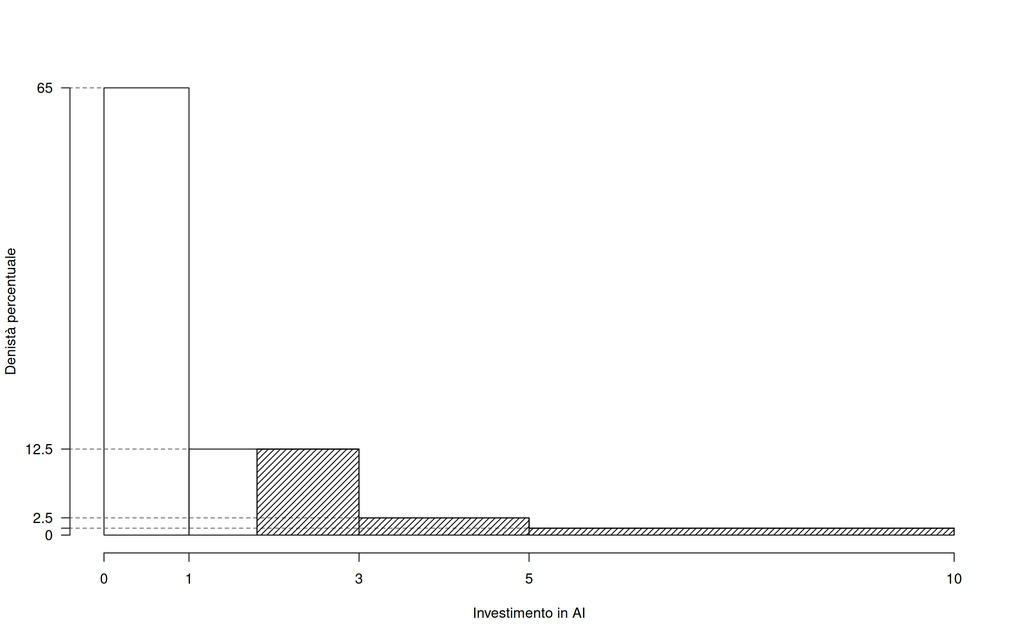

**1.b** (pt 1.2/31→4/103) Qual è il numero di aziende che hanno investito tra il 25-esimo e il 75-esimo percentile?

Per definizione $\%(x_{0.25}<X<x_{0.75})=50\%$ e $\#(x_{0.25}<X<x_{0.75})\approx0.5\times200 =100$

**1.c** (pt 0.6/31→2/103) Che relazione dobbiamo aspettarci tra media, mediana e moda?

**1.d** (pt 0.6/31→2/103) Siano $x_1,...,x_{10}$, $n=10$ numeri tali che
$$\sum_{i=1}^{10} x_i = 15$$
Posto
$$g(x)=\sum_{i=1}^{10}(x_i-x)^2$$
calcolare il valore di $x$ che minimizza $g$.

### Esercizio 2

Un processo viene svolto da due agenti AI, $A$ e $B$. L’agente $A$ commette un numero di allucinazioni che è distribuito secondo una Poisson di parametro 0.05, $X_A \sim \text{Pois}(0.05)$, mentre per l’agente $B$ il numero di allucinazioni è distribuito secondo una Poisson di parametro 0.03, $X_B \sim \text{Pois}(0.03)$, $X_A$ e $X_B$ indipendenti. Il processo finale viene considerato inconsistente se gli agenti hanno commesso almeno una allucinazione ($X_A+X_B\ge 1$).

**2.a** (pt 3.9/31→13/103) Calcolare la probabilità che il processo sia inconsistente ($X_A + X_B\ge 1$).

$$X_A + X_B \sim \text{Pois}(0.05+0.03)$$
$$\begin{eqnarray*}
P( X_A+X_B \geq 1 ) &=& 1-P( X_A+X_B < 1 )
\\ &=& 1-\left( \frac{ 0.08 ^{ 0 }}{ 0 !}e^{-
0.08 } \right)\\ &=& 1-( 0.9231
)\\ &=& 1- 0.9231
\\ &=& 0.0769
\end{eqnarray*}$$

**2.b** (pt 1.2/31→4/103) Si considerino $n=5$ ripetizioni indipendenti del processo. Per ogni ripetizione $i$, sia $X_i=X_A+X_B$ il numero totale di allucinazioni commesse dai due agenti nel processo $i$.

Calcolare la probabilità che almeno uno dei 5 processi risulti inconsistente, cioè che in almeno una ripetizione si abbia $X_i\ge 1$. (*Suggerimento: l’evento complementare di “almeno uno dei 5 processi è inconsistente” è “nessuno dei 5 processi è inconsistente”*)

$$\begin{eqnarray*}
P(X_A + X_B \ge 1) &=& 1 - P(X_A + X_B = 0) \\
&=& 0.0769\\
P(\text{almeno una volta}) &=& 1-P(\text{nessuna volta})\\
&=& 1-(1-0.0769)^5\\
&=& 0.3297
\end{eqnarray*}$$

**2.c** (pt 0.6/31→2/103) Sia $Z\sim N(0,1)$ e $Y\sim \text{Binom}(5,0.4)$, $Z$ e $Y$ indipendenti. Calcolare $E(Z-Y)$ e $V(Z-Y)$.

essendo

$$\begin{align}
E(Z) &= 0; & \qquad V(Z) & = 1\\
E(Y) &=5\times 0.4 = 2; & \qquad V(Y) & = 5\times
0.4\times(1-0.4)=1.2\\
\end{align}$$

e quindi

$$\begin{eqnarray*}
E(Z-Y) &=& 0-2\\
V(Z-Y) &=& 1+1.2\\
\end{eqnarray*}$$

**2.d** (pt 0.6/31→2/103) Siano $A\ne\emptyset$ e $B\ne\emptyset$, tali che $A\cap B = \emptyset$, $A$ e $B$ possono essere indipendenti? Perché?

### Esercizio 3

**3.a** (pt 3.9/31→13/103) Un’urna contiene 1 pallina numerata con $\fbox{0}$, 3 numerate con $\fbox{1}$ e 1 numerata con $\fbox{2}$. Si vince se esce $\fbox{1}$ oppure $\fbox{2}$ e si perde altrimenti. Si estrae 80 volte con reinserimento. Qual è la probabilità che la proporzione di vincite sia maggiore di 0.75?

**Teorema del Limite Centrale (proporzione)**

Siano $X_1$,…,$X_n$, $n=80$ VC IID, tc $X_i\sim\text{Ber}(\pi=0.8)$$,\forall i$, posto:
$$\hat\pi=\frac{S_n}n = \frac{X_1 + ... + X_n}n$$
allora:
$$\begin{eqnarray*}
\hat\pi & \mathop{\sim}\limits_{a}& N(\pi,\pi(1-\pi)/n) \\
&\sim & N\left(0.8,\frac{0.8\cdot(1-0.8)}{80}\right) \\
&\sim & N(0.8,0.002)
\end{eqnarray*}$$
$$\begin{eqnarray*}
P( \hat\pi > 0.75 )
&=& P\left( \frac { \hat\pi - \pi }{
\sqrt{\pi(1-\pi)/n} } > \frac { 0.75 - 0.8 }{\sqrt{ 0.002 }}
\right) \\
&=& P\left( Z > -1.12 \right)
\\ &=& 1-P(Z< -1.12 )\\
&=& 1-(1-\Phi( 1.12 )) \\ &=& 0.8686
\end{eqnarray*}$$

### Esercizio 4

**4.a** (pt 0.9/31→3/103) Siano $\hat\beta_0$, $\hat\beta_1$ e $\hat\sigma_\varepsilon$ gli stimatori di massima verosimiglianza di, $\beta_0$, $\beta_1$ e $\sigma_\varepsilon$, del modello di regressione lineare semplice
$$y_i = \beta_0 + \beta_1 x_i +\varepsilon_i, ~\varepsilon_i\sim
N(0,\sigma^2_\varepsilon),\forall i=1,...,n$$
Dimostrare la consistenza di $\hat\beta_0$.

Sappiamo che $\hat\beta_0$ è stimatore corretto di $\beta_0$ (teroema di Gauss-Markov):
$$E(\hat\beta_0)=\beta_0$$
Quindi, essendo corretto
$$\begin{eqnarray}
MSE(\hat\beta_0) &=& V(\hat\beta_0)\\
&=&\sigma_{\varepsilon}^{2} \left( \frac{1}
{n} + \frac{\bar{x}^{2}} {n \hat{\sigma}^{2}_{X}}
\right)\qquad\text{dal formulario}
\end{eqnarray}$$
Siccome
$$\lim_{n\to\infty}\sigma_{\varepsilon}^{2} \left( \frac{1}
{n} + \frac{\bar{x}^{2}} {n \hat{\sigma}^{2}_{X}} \right)=0$$
allora $\hat\beta_0$ è stimatore consistente di $\beta_0$.

**4.b** (pt 0.9/31→3/103) Siano $\hat\theta_1$ e $\hat\theta_2$ due stimatori **corretti** per $\theta$, cosa significa dire che $\hat\theta_1$ è più efficiente di $\hat\theta_2$?

**4.c** (pt 0.9/31→3/103) Definire gli errori di primo e secondo tipo di un test statistico e le relative probabilità.

Si definiscono

- L’**errore di primo tipo** è l’errore che si commette scegliendo $H_1$ quando è vera $H_0$.
- L’**errore di secondo tipo** è l’errore che si commette scegliendo $H_0$ quando è vera $H_1$.

|  |  | Decisione decido $H_0$ | Decisione decido $H_1$ |
| --- | --- | --- | --- |
| stato di natura | $H_0$ | $1-\alpha$ | $\alpha$ |
| stato di natura | $H_1$ | $\beta$ | $1-\beta$ |

$$\alpha=P(\text{Errore I
tipo})=P(\text{Decidere $H_1$};H_0)$$

$$\beta=P(\text{Errore II
tipo})=P(\text{Decidere $H_0$};H_1)$$

- $\alpha$ è il livello di **significatività** del test, $\alpha$ è la probabilità di scegliere $H_1$ quando invece è vera $H_0$.
- $\beta$ è la probabilità di scegliere $H_0$ quando invece è vera $H_1$.

**4.d** (pt 0.9/31→3/103) In un sondaggio su 160 persone è stato chiesto il livello di utilizzo di strumenti di Intelligenza Artificiale (Basso, Medio, Alto) e l’opinione sul loro impatto nel mondo del lavoro (Favorevole, Contrario).

|  | Livello di utilizzo Basso | Livello di utilizzo Medio | Livello di utilizzo Alto |
| --- | --- | --- | --- |
| **Opinione** |  |  |  |
| Favorevole | 30 | 10 | 35 |
| Contrario | 20 | 40 | 25 |

Eseguito il test del $\chi^2$ per verificare l’indipendenza tra il livello di utilizzo degli strumenti di AI e l’opinione sul loro impatto nel mondo del lavoro, si ottiene un $p_\text{value}=0.00002588$. Possiamo concludere che il livello di utilizzo e l’opinione sul loro impatto nel mondo del lavoro sono indipendenti? Perché?

Essendo $p_\text{value}=0.00002588<0.001$ il test è estremamente significativo, si rifiuta l’indipendenza tra il livello di utilizzo e l’opinione sull’impatto ad un livello di significatività inferiore all’1 per mille.

### Esercizio 5

In uno studio su $n=50$ municipalità dell’Unione Europea, sono stati analizzati il tasso di disoccupazione giovanile (in percentuale, $X$) e la disponibilità di aree verdi urbane (in metri quadrati per abitante, $Y$).

Si sono osservate le seguenti statistiche:
$$\begin{align*}
\sum_{i=1}^n x_i &= 498, &\sum_{i=1}^n x_i^2 &= 5025.18
& \\
\sum_{i=1}^n y_i &= 1289.27, &\sum_{i=1}^n y_i^2 &=
36923.54 &\sum_{i=1}^n x_iy_i &= 12393.43.
\end{align*}$$

**5.a** (pt 3.9/31→13/103) Per la regione $R$ si è osservato $x_R=10.6$ e $y_R=24.48$, stimare il modello di regressione dove $Y$ viene spiegata da $X$ e calcolare il residuo per la regione $R$.

$$\begin{eqnarray*}
\bar x &=&\frac 1 n\sum_{i=1}^n x_i = \frac {1}{ 50
} 498 = 9.96 \\
\bar y &=&\frac 1 n\sum_{i=1}^n y_i = \frac {1}{ 50
} 1289.27 = 25.79 \\
\hat\sigma_X^2&=&\frac 1 n\sum_{i=1}^n x_i^2-\bar
x^2=\frac {1}{ 50 } 5025 - 9.96 ^2= 1.302 \\
\hat\sigma_Y^2&=&\frac 1 n\sum_{i=1}^n y_i^2-\bar
y^2=\frac {1}{ 50 } 36924 - 25.7854 ^2= 73.58 \\
\text{cov}(X,Y)&=&\frac 1 n\sum_{i=1}^n x_i~y_i-\bar
x\bar y=\frac {1}{ 50 } 12393 - 9.96 \cdot 25.7854 = -8.954 \\
\hat\beta_1 &=&
\frac{\text{cov}(X,Y)}{\hat\sigma_X^2} \\
&=& \frac{ -8.954 }{ 1.302 } = -6.877 \\
\hat\beta_0 &=& \bar y - \hat\beta_1 \bar x\\
&=& 25.79 - (-6.8771) \times 9.96 = 94.28
\end{eqnarray*}$$
$$\begin{eqnarray*}
\hat y_i &=&\hat\beta_0+\hat\beta_1 x_i=\\
&=& 94.28 + (-6.8771) \times 10.6 = 21.38 \\
\hat \varepsilon_i &=& y_i-\hat y_i\\
&=& 24.48 - 21.3841 = 3.098
\end{eqnarray*}$$

**5.b** (pt 1.2/31→4/103) Determinare la percentuale di varianza spiegata dal modello.

$$\begin{eqnarray*}
r&=&\frac{\text{cov}(X,Y)}{\sigma_X\sigma_Y}=\frac{ -8.954 }{
1.141 \times 8.578 }= -0.9148 \\
r^2&=& 0.8368 > 0.75
\end{eqnarray*}$$

Il modello si adatta bene ai dati.

Il modello spiega il $83.68\%$ della variabilità totale della $Y$.

$\fbox{A}$ FORMULAZIONE DELLE IPOTESI

$$\begin{cases}
H_0: \beta_1 = \beta_{1;H_0}=-5.5 \\
H_1: \beta_1 \neq \beta_{1;H_0}=-5.5
\end{cases}$$

$\fbox{B}$ SCELTA E CALCOLO STATISTICA-TEST, $T$ Test su un coefficiente di regressione: $\Rightarrow$ t-Test.

$$\begin{eqnarray*}
\hat{\sigma_\varepsilon}^2&=&(1-r^2)\hat\sigma_Y^2\\
&=& (1- 0.8369 )\times 73.58 \\
&=& 12.01 \\
S_\varepsilon^2 &=& \frac{n} {n-2}
\hat{\sigma_\varepsilon}^2\\
&=& \frac{ 50 } { 50 -2} \hat{\sigma_\varepsilon}^2 \\
&=& \frac{ 50 } { 50 -2} \times 12.01 = 12.51
\end{eqnarray*}$$

E quindi
$$\begin{eqnarray*}
V(\hat\beta_{1}) &=& \frac{\sigma_{\varepsilon}^{2}} {n
\hat{\sigma}^{2}_{X}} \\
\widehat{V(\hat\beta_{1})} &=& \frac{S_{\varepsilon}^{2}} {n
\hat{\sigma}^{2}_{X}} \\
&=& \frac{ 12.51 } { 50 \times 1.302 } = 0.1921 \\
\widehat{SE(\hat\beta_{1})} &=& \sqrt{ 0.1921 }\\
&=& 0.4383
\end{eqnarray*}$$

$$\begin{eqnarray*}
\frac{\hat\beta_{ 1 } - \beta_{ 1 ;H_0}} {\widehat{SE(\hat\beta_{ 1
})}}&\sim&t_{n-2}\\
t_{\text{obs}}
&=& \frac{ ( -6.877 - -5.5 )} { 0.4383 }
= -3.142 \, .
\end{eqnarray*}$$

$\fbox{C}$ CONCLUSIONE

Siccome $H_1$ è bilaterale, considereremo $\alpha/2$, anziché $\alpha$

$\alpha=0.1, 0.05, 0.01, 0.001$ e quindi $\alpha/2=0.05, 0.025, 0.005, 0.0005$

I valori critici sono

$t_{50-2;0.05}=1.6772$; $t_{50-2;0.025}=2.0106$; $t_{50-2;0.005}=2.6822$; $t_{50-2;0.0005}=3.5051$

Siccome $2.6822<|t_\text{obs}|=3.1416<3.5051$, quindi **rifiuto** $H_0$ all’1%,

$0.001<p_\text{value}<0.01$, *molto significativo* $\fbox{**}$.

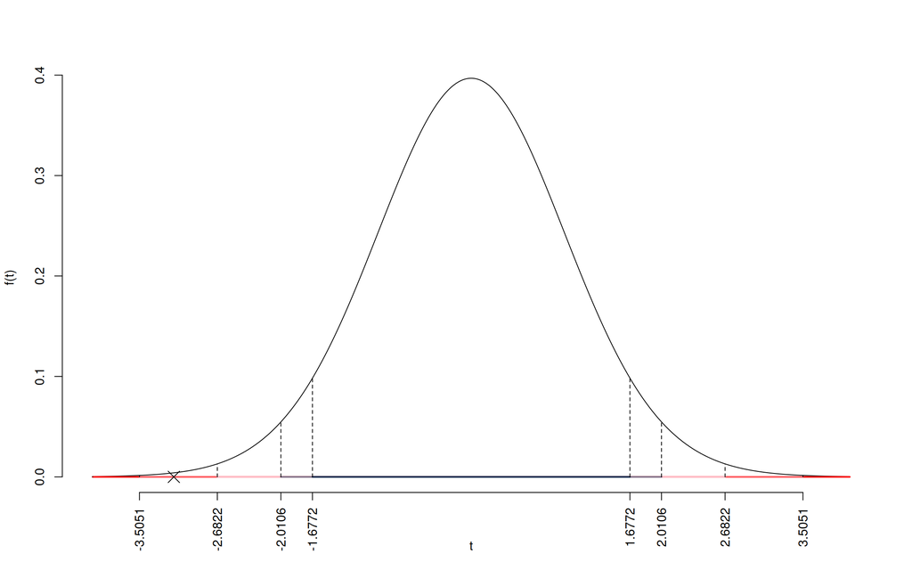

Il $p_{\text{value}}$ è

$$p_{\text{value}} =
P(|T_{50-2}|>|-3.14|)=2P(T_{50-2}>3.14)=0.002877$$

Attenzione il calcolo del $p_\text{value}$ con la $T$ è puramente illustrativo e non può essere riprodotto senza una calcolatrice statistica adeguata.
$$0.001 < p_\text{value}= 0.002877 \leq 0.01$$

**5.d** (pt 0.6/31→2/103) Perché, nel modello stimato al punto 5a, una previsione per $x=10$ è più precisa di una previsione per $x=100$?

**5.e** (pt 0.6/31→2/103) Se in un modello di regressione lineare $\hat\beta_1 =0$ quanto vale $r$?

**5.f** (pt 0.6/31→2/103) In un modello di regressione lineare, cosa comporta $r=-1$?

# Prova di Statistica B

### Esercizio 1

Su un campione di $150$ aziende con più di 50 addetti dell’Emilia-Romagna è stato rilevato l’investimento effettuato negli ultimi 5 anni in intelligenza artificiale (espresso in milioni di euro). Di seguito è riportata la distribuzione delle densità percentuali:

| $[\text{x}_j,$ | $\text{x}_{j+1})$ | $h_j$ |
| --- | --- | --- |
| 0 | 1 | 30.0 |
| 1 | 2 | 40.0 |
| 2 | 6 | 5.0 |
| 6 | 10 | 2.5 |

**1.a** (pt 3.9/31→13/103) Calcolare il valore approssimativo della mediana.

| $[\text{x}_j,$ | $\text{x}_{j+1})$ | $n_j$ | $f_j$ | $b_j$ | $h_j$ |
| --- | --- | --- | --- | --- | --- |
| 0 | 1 | 45 | 0.3 | 1 | 30.0 |
| 1 | 2 | 60 | 0.4 | 1 | 40.0 |
| 2 | 6 | 30 | 0.2 | 4 | 5.0 |
| 6 | 10 | 15 | 0.1 | 4 | 2.5 |
|  |  | 150 | 1.0 | 10 |  |

$$\begin{eqnarray*}
p &=& 0.5 , \text{essendo }F_{ 2 }= 0.7 >
0.5 \Rightarrow j_{ 0.5 }= 2 \\
x_{ 0.5 } &=& x_{\text{inf}; 2 } + \frac{ { 0.5 } - F_{ 1 }}
{f_{ 2 }} \cdot b_{ 2 } \\
&=& 1 + \frac {{ 0.5 } - 0.3 } { 0.4 }
\cdot 1 \\
&=& 1.5
\end{eqnarray*}$$

[figure not shown]

**1.b** (pt 1.2/31→4/103) Qual è il numero approssimativo di aziende che hanno investito più di 3 milioni di euro?

$$\begin{eqnarray*}
\%(X> 3 ) &=& ( 6 - 3 )\times h_{ 3 }+ f_{ 4 }\times 100
\\
&=& ( 3 )\times 5 + ( 0.1 )\times 100 \\
&=& 0.25 \times(100)\\
\#(X> 3 ) &\approx& 38
\end{eqnarray*}$$

**1.c** (pt 0.6/31→2/103) Sapendo che le media è pari a $2.4$ e considerata la mediana calcolata al punto 1.a, che forma avrà l’istogramma di densità?

**1.d** (pt 0.6/31→2/103) L’investimento medio è pari a $\bar x=2.4$, mentre la varianza è pari a $\sigma^2=5.1$. Se ogni impresa aumentasse il proprio investimento di un milione di euro, quanto varrebbero la media e la varianza dei dati così trasformati?

$$\bar y= 3.4 ~~~~~~~~ \sigma^2_Y= 5.1$$

### Esercizio 2

Un processo viene svolto da due agenti AI in sequenza, prima $A$ e poi $B$. Il tempo impiegato dall’agente $A$, misurato in secondi, è distribuito secondo una Normale con media 8 e varianza 1, $X_A \sim N(8,1)$, mentre il tempo impiegato dall’agente $B$ è distribuito secondo una Normale con media 10 e varianza 3, $X_B \sim N(10,3)$, con $X_A$ e $X_B$ indipendenti. Il processo finale viene considerato troppo lento se il tempo complessivo supera 22 secondi.

**2.a** (pt 3.9/31→13/103) Calcolare la probabilità che il processo sia troppo lento ($P(X_A+X_B>22)$).

$$X=X_A + X_B \sim N(8+10,1+3)$$
$$\begin{eqnarray*}
P( X > 22 )
&=& P\left( \frac { X - \mu }{ \sigma } > \frac
{ 22 - 18 }{\sqrt{ 4 }} \right) \\
&=& P\left( Z > 2 \right)
\\ &=& 1-P(Z< 2 )\\
&=& 1-\Phi( 2 ) \\ &=& 0.0228
\end{eqnarray*}$$

**2.b** (pt 1.2/31→4/103) Calcolare $P(X_A + X_B\le 23|X_A + X_B> 22)$.

$$X=X_A + X_B \sim N(8+10,1+3)$$

$$\begin{eqnarray*}
P(X\le 23|X> 22) &=& \frac{P(X\le 23\cap X> 22)}{P(X>
22)}\\
&=& \frac{P(22<X\le 23)}{P(X> 22)}\\
&=& \frac{0.9938-0.9772}{0.0228}\\
&=& 0.727
\end{eqnarray*}$$

**2.c** (pt 0.6/31→2/103) Siano $X_1\sim \text{Ber}(0.5)$, $X_2\sim \text{Ber}(0.5)$ e $X_3\sim \text{Ber}(0.5)$, 3 Bernoulli indipendenti. Come si distribuisce $X=X_1+X_2+X_3$?

$$X_1+X_2+X_3 \sim \text{Binom}(3,0.5)$$

**2.d** (pt 0.6/31→2/103) Siano $A$ e $B$ due eventi, tali che $P(B|A)=0.5$, $P(B|\bar A)=0.4$ e $P(A)=0.3$, calcolare $P(B)$.

$$\begin{eqnarray*}
P(B) &=& P(B|A)P(A)+P(B|\bar A)P(\bar A)\\
&=& 0.5\times 0.3+ 0.4\times(1-0.3)\\
&=& 0.43
\end{eqnarray*}$$

### Esercizio 3

**3.a** (pt 3.9/31→13/103) Un’urna contiene 1 pallina numerata con $\fbox{0}$, 3 numerate con $\fbox{1}$ e 1 numerata con $\fbox{2}$. Si vince se esce $\fbox{1}$ oppure $\fbox{2}$ e si perde altrimenti. Si estrae 80 volte con reinserimento. Qual è la probabilità di vincere meno di 60 volte?

**Teorema del Limite Centrale (somma di Bernoulli)**

Siano $X_1$,…,$X_n$, $n=80$ VC IID, tc $X_i\sim\text{Ber}(\pi=0.8)$$,\forall i$, posto:
$$S_n = X_1 + ... + X_n$$
allora:
$$\begin{eqnarray*}
S_n & \mathop{\sim}\limits_{a}& N(n\pi,n\pi(1-\pi)) \\
&\sim & N(80\cdot0.8,80\cdot0.8\cdot(1-0.8)) \\
&\sim & N(64,12.8)
\end{eqnarray*}$$
$$\begin{eqnarray*}
P( S_n < 60 )
&=& P\left( \frac { S_n - n\pi }{ \sqrt{n\pi(1-\pi)}
} < \frac { 60 - 64 }{\sqrt{ 12.8 }} \right) \\
&=& P\left( Z < -1.12 \right) \\
&=& 1-\Phi( 1.12 ) \\ &=& 0.1314
\end{eqnarray*}$$

### Esercizio 4

**4.a** (pt 0.9/31→3/103) Siano $\hat\beta_0$, $\hat\beta_1$ e $\hat\sigma_\varepsilon$ gli stimatori di massima verosimiglianza di, $\beta_0$, $\beta_1$ e $\sigma_\varepsilon$, del modello di regressione lineare semplice
$$y_i = \beta_0 + \beta_1 x_i +\varepsilon_i, ~\varepsilon_i\sim
N(0,\sigma^2_\varepsilon),\forall i=1,...,n$$
Dimostrare la consistenza di $\hat\beta_1$.

Sappiamo che $\hat\beta_1$ è stimatore corretto di $\beta_1$ (teorema di Gauss-Markov):
$$E(\hat\beta_1)=\beta_1$$
Quindi, essendo corretto
$$\begin{eqnarray}
MSE(\hat\beta_1) &=& V(\hat\beta_1)\\
&=&\frac{\sigma_{\varepsilon}^{2}} {n
\hat{\sigma}^{2}_{X}} \qquad \text{dal formulario}
\end{eqnarray}$$
Siccome
$$\lim_{n\to\infty}\frac{\sigma_{\varepsilon}^{2}} {n
\hat{\sigma}^{2}_{X}}=0$$
allora $\hat\beta_1$ è stimatore consistente di $\beta_1$.

**4.b** (pt 0.9/31→3/103) Siano $\hat\theta_1$ e $\hat\theta_2$ due stimatori **non corretti** per $\theta$, cosa significa dire che $\hat\theta_1$ è più efficiente di $\hat\theta_2$?

**4.c** (pt 0.9/31→3/103) Si consideri il seguente sistema d’ipotesi:
$$\begin{cases}
H_0:\theta=\theta_0\\
H_1:\theta>\theta_0
\end{cases}$$

Posta con $T$ la VC statistica test e con $t_\text{obs}$ il valore osservato della statistica test, definire il $p_\text{value}$ del test.

Il $p_\text{value}$ è la probabilità, se fosse vera $H_0$ di avere un campione ancora più favorevole ad $H_1$ di quello che abbiamo osservato, in altre parole ci dice quanto è raro il campione sotto ipotesi $H_0$. In simboli, nel caso di un test unilaterale destro
$$p_\text{value} = P(T>t_\text{obs})$$

**4.d** (pt 0.9/31→3/103) In un sondaggio su 273 lavoratori è stato chiesto il livello di formazione ricevuta sull’uso degli strumenti di Intelligenza Artificiale (Basso, Medio, Alto) e la valutazione della propria preparazione rispetto ai cambiamenti tecnologici nel lavoro (Adeguata, Insufficiente).

|  | Livello di formazione Basso | Livello di formazione Medio | Livello di formazione Alto |
| --- | --- | --- | --- |
| **Preparazione** |  |  |  |
| Adeguata | 18 | 32 | 45 |
| Insufficiente | 40 | 40 | 98 |

Eseguito il test del $\chi^2$ per verificare l’indipendenza tra il livello di formazione sugli strumenti di AI e la valutazione della preparazione rispetto ai cambiamenti tecnologici, si ottiene un $p_\text{value}=0.1344$. Possiamo concludere che il livello di formazione ricevuta e la propria valutazione rispetto alla propria preparazione sono indipendenti? Perché?

Essendo $p_\text{value}=0.1344>0.1$ il test non è significativo, non si rifiuta l’indipendenza tra il livello di utilizzo e l’opinione sull’impatto per nessun livello di significatività.

### Esercizio 5

In uno studio su $n=50$ municipalità dell’Unione Europea, sono stati analizzati il tasso di disoccupazione giovanile (in percentuale, $X$) e il numero di posti a sedere in teatro e cinema per abitante ($Y$).

Si sono osservate le seguenti statistiche:
$$\begin{align*}
\sum_{i=1}^n x_i &= 500.4, &\sum_{i=1}^n x_i^2 &= 5047.02
& \\
\sum_{i=1}^n y_i &= 114.68, &\sum_{i=1}^n y_i^2 &= 263.79
&\sum_{i=1}^n x_iy_i &= 1151.3.
\end{align*}$$

**5.a** (pt 3.9/31→13/103) Per la regione $R$ si è osservato $x_R=10.5$ e $y_R=2.19$, stimare il modello di regressione dove $Y$ viene spiegata da $X$ e calcolare il residuo per la regione $R$.

$$\begin{eqnarray*}
\bar x &=&\frac 1 n\sum_{i=1}^n x_i = \frac {1}{ 50
} 500.4 = 10.01 \\
\bar y &=&\frac 1 n\sum_{i=1}^n y_i = \frac {1}{ 50
} 114.68 = 2.294 \\
\hat\sigma_X^2&=&\frac 1 n\sum_{i=1}^n x_i^2-\bar
x^2=\frac {1}{ 50 } 5047 - 10.008 ^2= 0.7803 \\
\hat\sigma_Y^2&=&\frac 1 n\sum_{i=1}^n y_i^2-\bar
y^2=\frac {1}{ 50 } 263.8 - 2.2936 ^2= 0.0152 \\
\text{cov}(X,Y)&=&\frac 1 n\sum_{i=1}^n x_i~y_i-\bar
x\bar y=\frac {1}{ 50 } 1151 - 10.008 \cdot 2.2936 = 0.07166 \\
\hat\beta_1 &=&
\frac{\text{cov}(X,Y)}{\hat\sigma_X^2} \\
&=& \frac{ 0.07166 }{ 0.7803 } = 0.09183
\\
\hat\beta_0 &=& \bar y - \hat\beta_1 \bar x\\
&=& 2.294 - 0.0918 \times 10.008 = 1.375
\end{eqnarray*}$$
$$\begin{eqnarray*}
\hat y_i &=&\hat\beta_0+\hat\beta_1 x_i=\\
&=& 1.375 + 0.0918 \times 10.5 = 2.339 \\
\hat \varepsilon_i &=& y_i-\hat y_i\\
&=& 2.192 - 2.3388 = -0.1471
\end{eqnarray*}$$

**5.b** (pt 1.2/31→4/103) Determinare la percentuale di varianza spiegata dal modello.

$$\begin{eqnarray*}
r&=&\frac{\text{cov}(X,Y)}{\sigma_X\sigma_Y}=\frac{ 0.07166 }{
0.8834 \times 0.1233 }= 0.658 \\
r^2&=& 0.4329 < 0.75
\end{eqnarray*}$$

Il modello **non** si adatta bene ai dati.

Il modello spiega il $43.29\%$ della variabilità totale della $Y$.

**5.c** (pt 3.9/31→13/103) Testare l’ipotesi che $\beta_0 = 1$ contro l’alternativa che sia maggiore, per $\alpha=0.1,0.05,0.01,0.001$ e dare una valutazione approssimativa del $p_\text{value}$ (ad esempio il $p_\text{value}$ è minore di 0.001, compreso tra 0.05 e tra 0.01, ecc.).

$\fbox{A}$ FORMULAZIONE DELLE IPOTESI

$$\begin{cases}
H_0: \beta_0 = \beta_{0;H_0}=1 \\
H_1: \beta_0 > \beta_{0;H_0}=1
\end{cases}$$

$\fbox{B}$ SCELTA E CALCOLO STATISTICA-TEST, $T$ Test su un coefficiente di regressione: $\Rightarrow$ t-Test.

$$\begin{eqnarray*}
\hat{\sigma_\varepsilon}^2&=&(1-r^2)\hat\sigma_Y^2\\
&=& (1- 0.433 )\times 0.0152 \\
&=& 0.0086 \\
S_\varepsilon^2 &=& \frac{n} {n-2}
\hat{\sigma_\varepsilon}^2\\
&=& \frac{ 50 } { 50 -2} \hat{\sigma_\varepsilon}^2 \\
&=& \frac{ 50 } { 50 -2} \times 0.0086 = 0.009
\end{eqnarray*}$$

E quindi
$$\begin{eqnarray*}
V(\hat\beta_{0}) &=& \sigma_{\varepsilon}^{2} \left( \frac{1}
{n} + \frac{\bar{x}^{2}} {n \hat{\sigma}^{2}_{X}} \right)\\
\widehat{V(\hat\beta_{0})} &=& S_{\varepsilon}^{2}\left(
\frac{1} {n} + \frac{\bar{x}^{2}} {n \hat{\sigma}^{2}_{X}} \right)\ \\
&=& 0.009 \times\left( \frac{1} { 50 } + \frac{ 10.01 ^{2}} {
50 \times 0.7803 } \right)\\
\widehat{SE(\hat\beta_{0})} &=& \sqrt{ 0.0232 }\\
&=& 0.1523
\end{eqnarray*}$$
$$\begin{eqnarray*}
\frac{\hat\beta_{ 0 } - \beta_{ 0 ;H_0}} {\widehat{SE(\hat\beta_{ 0
})}}&\sim&t_{n-2}\\
t_{\text{obs}}
&=& \frac{ ( 1.375 - 1 )} { 0.1524 }
= 2.458 \, .
\end{eqnarray*}$$

$\fbox{C}$ CONCLUSIONE

Consideriamo $\alpha=0.1, 0.05, 0.01, 0.001$

I valori critici sono

$t_{50-2;0.1}=1.2994$; $t_{50-2;0.05}=1.6772$; $t_{50-2;0.01}=2.4066$; $t_{50-2;0.001}=3.2689$

Siccome $2.4066<t_\text{obs}=2.4579<3.2689$, quindi **rifiuto** $H_0$ all’1%,

$0.001<p_\text{value}<0.01$, *molto significativo* $\fbox{**}$.

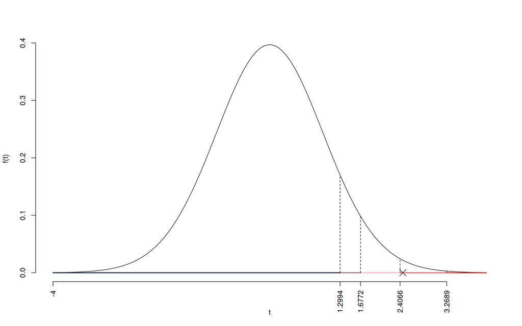

Il $p_{\text{value}}$ è

$$p_{\text{value}} =
P(T_{50-2}>2.46)=0.008819$$

Attenzione il calcolo del $p_\text{value}$ con la $T$ è puramente illustrativo e non può essere riprodotto senza una calcolatrice statistica adeguata.
$$0.001 < p_\text{value}= 0.008819 \leq 0.01$$

**5.d** (pt 0.6/31→2/103) Che differenza c’è tra interpolazione ed estrapolazione?

**5.e** (pt 0.6/31→2/103) Se in un modello di regressione $\hat\beta_1 <0$ che segno avrà $r$?

**5.f** (pt 0.6/31→2/103) Cosa significa dire che $r^2$ è invariante ai cambiamenti di scala?

Significa che se $V=a+bY$ e $W=c+dX$ allora $r^2_{VW}=r^2_{XY}$.

# Prova di Statistica C

### Esercizio 1

Su un campione di $200$ aziende con più di 50 addetti dell’Emilia-Romagna è stato rilevato l’investimento effettuato negli ultimi 5 anni in intelligenza artificiale (espresso in milioni di euro). Di seguito è riportata la distribuzione delle frequenze cumulate:

| $[\text{x}_j,$ | $\text{x}_{j+1})$ | $F_j$ |
| --- | --- | --- |
| 0 | 2 | 0.10 |
| 2 | 3 | 0.50 |
| 3 | 7 | 0.95 |
| 7 | 15 | 1.00 |

**1.a** (pt 3.9/31→13/103) Individuare la classe modale.

| $[\text{x}_j,$ | $\text{x}_{j+1})$ | $n_j$ | $f_j$ | $b_j$ | $h_j$ |
| --- | --- | --- | --- | --- | --- |
| 0 | 2 | 20 | 0.10 | 2 | 5.00 |
| 2 | 3 | 80 | 0.40 | 1 | 40.00 |
| 3 | 7 | 90 | 0.45 | 4 | 11.25 |
| 7 | 15 | 10 | 0.05 | 8 | 0.62 |
|  |  | 200 | 1.00 | 15 |  |

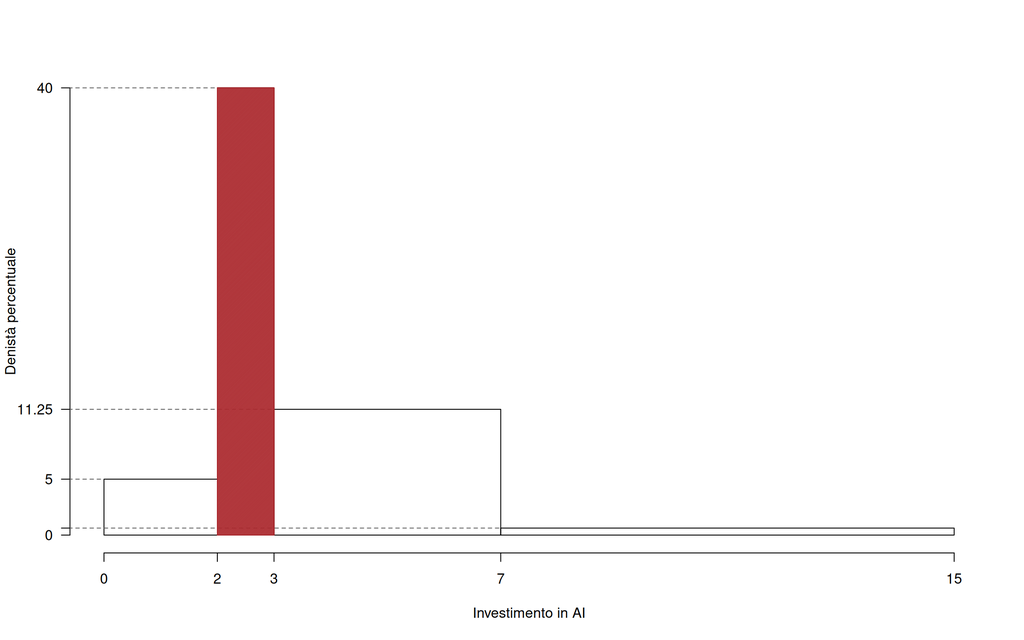

**1.b** (pt 1.2/31→4/103) Qual è il numero approssimativo di aziende che hanno investito tra il 15-esimo e il 25-esimo percentile?

Per definizione $\%(x_{0.15}<X<x_{0.25})=10\%$ e $\#(x_{0.15}<X<x_{0.25})\approx0.1\times200 =20$

**1.c** (pt 0.6/31→2/103) Sapendo che le media è pari a $3.9$ e considerata la mediana calcolata al punto 1.a, che forma avrà l’istogramma di densità?

**1.d** (pt 0.6/31→2/103) L’investimento medio è pari a $\bar x=3.9$, mentre la SD è pari a $\sigma=2.2$. Se ogni impresa aumentasse il proprio investimento del 10%, quanto varrebbero la media e la SD dei dati così trasformati?

$$\bar y= 4.29 ~~~~~~~~ \sigma_Y= 2.42$$

### Esercizio 2

Un processo è svolto da $n=5$ agenti AI, ogni agente commette un’allucinazione con probabilità $\pi=0.25$. Sia $X_i$ la VC che vale 1 se l’agente $i$ ha commesso un’allucinazione e vale 0 altrimenti:
$$P(X_i = 1) = 0.25, \qquad i =1,...,5$$
e sia
$$X=X_1+...+X_5$$
la VC che conta il numero di allucinazioni su 5 agenti.

**2.a** (pt 3.9/31→13/103) Calcolare la probabilità che il processo abbia al massimo un’allucinazione ($P(X\le 1)$).

$$X=X_1 + ... + X_5 \sim \operatorname{Binom}(5;0.25)$$
$$\begin{eqnarray*}
P( X \leq 1 ) &=& \binom{ 5 }{ 0 } 0.25 ^{ 0 }(1- 0.25 )^{
5 - 0 }+\binom{ 5 }{ 1 } 0.25 ^{ 1 }(1- 0.25 )^{ 5 - 1 }
\\ &=& 0.2373+0.3955
\\ &=& 0.6328
\end{eqnarray*}$$

**2.b** (pt 1.2/31→4/103) Calcolare $P(X\le 1|X\le 2)$.

$$X=X_1 + ... + X_5 \sim \operatorname{Binom}(5;0.25)$$

$$\begin{eqnarray*}
P(X\le 1|X\le 2) &=& \frac{P(X\le 1\cap X\le 2)}{P(X\le 2)}\\
&=& \frac{P(X\le 1)}{P(X\le 2)}\\
&=& \frac{0.6328}{0.8965}\\
&=& 0.7059
\end{eqnarray*}$$

**2.c** (pt 0.6/31→2/103) Siano $Z\sim N(0,1)$, $X\sim \chi^2_2$ e $Y\sim \chi^2_5$, $X$, $Y$ e $Z$ indipendenti. Come si distribuisce
$$\frac{Z}{\sqrt{(X+Y)/7}}\sim~~?$$

$$X+Y \sim \chi^2_{2+5}$$
e quindi
$$\frac{Z}{\sqrt{(X+Y)/7}}\sim t_7$$

**2.d** (pt 0.6/31→2/103) Siano $A$ e $B$ due eventi tali che $P(B)=0.5$ e $P(A)=0.6$, $A$ e $B$ possono essere incompatibili? Perché?

No, perché se lo fossero avremmo che $P(A\cap B)=0$ e di conseguenza
$$P(A\cup B)= P(A)+P(B)=0.5+0.6> 1$$
che è impossibile.

### Esercizio 3

**3.a** (pt 3.9/31→13/103) Un’urna contiene 1 pallina numerata con $\fbox{0}$, 3 numerate con $\fbox{1}$ e 1 numerata con $\fbox{2}$. Si estrae 80 volte con reinserimento. Qual è la probabilità che la somma delle 80 palline sia inferiore a 75?

$$\begin{eqnarray*}
\mu &=& \frac 1{ 5 }( 0 + 1 + 1 + 1 + 2 )= 1 \\
\sigma^2 &=& \frac 1{ 5 }( 0 ^2+ 1 ^2+ 1 ^2+ 1 ^2+ 2 ^2 )-( 1
)^2= 0.4
\end{eqnarray*}$$
**Teorema del Limite Centrale (somma VC qualunque)**

Siano $X_1$,…,$X_n$, $n=80$ VC IID, tc $E(X_i)=\mu=1$ e $V(X_i)=\sigma^2=0.4,\forall i$, posto:
$$S_n = X_1 + ... + X_n$$
allora:
$$\begin{eqnarray*}
S_n & \mathop{\sim}\limits_{a}& N(n\mu,n\sigma^2) \\
&\sim & N(80\cdot1,80\cdot0.4) \\
&\sim & N(80,32)
\end{eqnarray*}$$
$$\begin{eqnarray*}
P( S_n < 75 )
&=& P\left( \frac { S_n - n\mu }{ \sqrt{n\sigma^2}
} < \frac { 75 - 80 }{\sqrt{ 32 }} \right) \\
&=& P\left( Z < -0.88 \right) \\
&=& 1-\Phi( 0.88 ) \\ &=& 0.1894
\end{eqnarray*}$$

### Esercizio 4

**4.a** (pt 0.9/31→3/103) Siano $\hat\beta_0$, $\hat\beta_1$ e $\hat\sigma_\varepsilon$ gli stimatori di massima verosimiglianza di, $\beta_0$, $\beta_1$ e $\sigma_\varepsilon$, del modello di regressione lineare semplice
$$y_i = \beta_0 + \beta_1 x_i +\varepsilon_i, ~\varepsilon_i\sim
N(0,\sigma^2_\varepsilon),\forall i=1,...,n$$
Sapendo che:
$$V(\hat\sigma_\varepsilon)=\frac{2(n-2)}{n^2}\sigma_\varepsilon^4$$
Dimostrare la consistenza di $\hat\sigma_\varepsilon^2$.

**4.b** (pt 0.9/31→3/103) Sia $\hat\theta$ lo stimatore di massima verosimiglianza per $\theta$, indicare la sua distribuzione asintotica.

**4.c** (pt 0.9/31→3/103) Definire un intervallo di confidenza al 95% per un generico parametro $\theta$.

Un intervallo di confidenza al livello 95% per $\theta$ è un intervallo costruito sui dati in modo tale che il 95% delle volte contenga il vero parametro $\theta$. Ovvero è una coppia di statistiche $L_1(X_1,...,X_n)<L_2(X_1,...,X_n)$ tali che
$$P([L_1(X_1,...,X_n),L_2(X_1,...,X_n)]\ni\theta)=0.95$$

**4.d** (pt 0.9/31→3/103) Una moneta, che non sappiamo se è perfetta oppure no, viene lanciata 100 volte. Abbiamo osservato 34 volte testa su 100 lanci. Posto $\pi$ la probabilità che la moneta mostri testa, si è testato
$$\begin{cases}
H_0:\pi=\frac 12\\
H_1:\pi\ne\frac 12
\end{cases}$$
ed è risultato $p_\text{value}=0.0014$. Possiamo concludere che la moneta sia truccata? Perché?

### Esercizio 5

In un’indagine sulla penetrazione dell’intelligenza artificiale (IA) nel mondo del lavoro sono state indagate 75 aziende con oltre i 50 dipendenti della regione Lombardia. L’indagine ha mostrato che 45 aziende su 75 hanno integrato i loro processi produttivi con sistemi IA.

**5.a** (pt 0.9/31→3/103) Costruire un intervallo di confidenza al 95 % per la proporzione di aziende che in Lombardia integrano i loro processi con l’IA.

$1-\alpha =0.95$ e quindi $\alpha=0.05\rightarrow \alpha/2=0.025$

$$\hat\pi = \frac{S_n}n = \frac{ 45 }{ 75 }= 0.6$$

$$\begin{eqnarray*}
Idc: & & \hat\pi \pm z_{\alpha/2} \times
\sqrt{\frac{\hat\pi(1-\hat\pi)}{n}} \\
& & 0.6 \pm 1.96 \times \sqrt{\frac{ 0.6 (1- 0.6 )}{ 75
}} \\
& & 0.6 \pm 1.96 \times 0.05657 \\
& & [ 0.4891 , 0.7109 ]
\end{eqnarray*}$$

**5.b** (pt 3.0/31→10/103) Un’indagine analoga, condotta sul territorio nazionale, ha mostrato che la proporzione di aziende che integrano l’IA nei loro processi è pari 0.55. Testare l’ipotesi che la proporzione di aziende che usano le IA nella regione Lombardia sia uguale a quella del resto d’Italia contro l’alternativa che sia maggiore. Risolvere con il $p_\text{value}$ e confrontarlo per $\alpha = 0.1,\ 0.05,\ 0.01,\ 0.001$.

**Test $Z$ per una proporzione**

La stima
$$\hat\pi=\frac { 45 } { 75 }=
0.6$$

$\fbox{A}$ FORMULAZIONE DELLE IPOTESI

$$\begin{cases}
H_0: \pi = \pi_0=0.55 \\
H_1: \pi > \pi_0=0.55
\end{cases}$$

$\fbox{B}$ SCELTA E CALCOLO STATISTICA-TEST, $Z$ Test Binomiale per $n$ grande: $\Rightarrow$ z-Test.

$$\begin{eqnarray*}
\frac{\hat\pi - \pi_{0}} {\sqrt
{\pi_0(1-\pi_0)/\,n}}&\sim&N(0,1)\\
z_{\text{obs}}
&=& \frac{ ( 0.6 - 0.55 )} {\sqrt{ 0.55 (1- 0.55 )/ 75 }}
= 0.8704 \,.
\end{eqnarray*}$$

$\fbox{C}$ CONCLUSIONE

Il $p_{\text{value}}$ è

$$p_{\text{value}} =
P(Z>0.87)=0.192044$$

$$0.1 < p_\text{value}= 0.192044 \leq 1$$

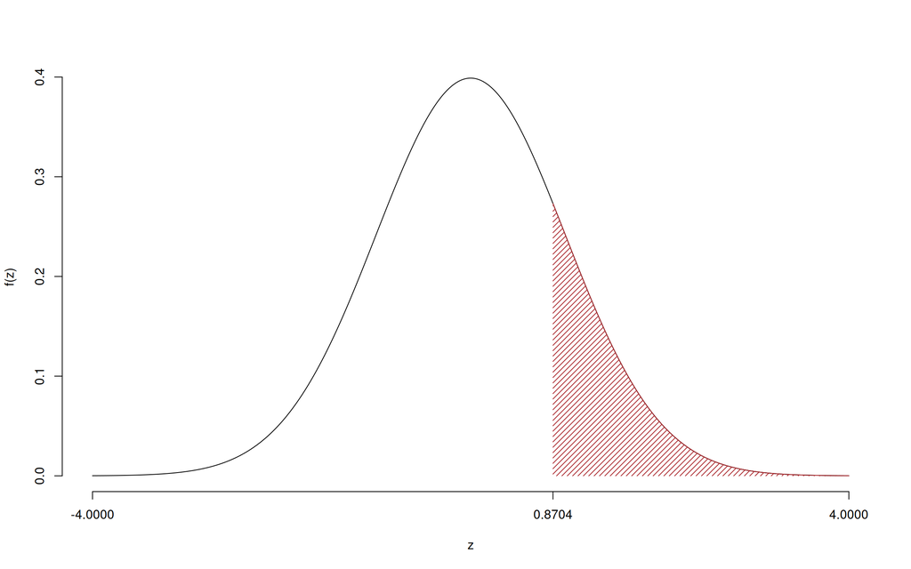

**Non** rifiuto $H_0$ a **nessun** livello di significatività,

$p_\text{value}>0.1$, *non significativo*

### Esercizio 6

In uno studio su $n=50$ municipalità dell’Unione Europea, sono stati analizzati il numero di centraline per la ricarica delle auto elettriche per chilometro quadrato (X) e una misura della qualità dell’aria espressa in opportuna scala (Y).

Si sono osservate le seguenti statistiche:
$$\begin{align*}
\sum_{i=1}^n x_i &= 497.7, &\sum_{i=1}^n x_i^2 &= 5123.67
& \\
\sum_{i=1}^n y_i &= 113.92, &\sum_{i=1}^n y_i^2 &= 262.03
&\sum_{i=1}^n x_iy_i &= 1151.85.
\end{align*}$$

**6.a** (pt 3.9/31→13/103) Per la regione $R$ si è osservato $x_R=10.1$ e $y_R=2.24$, stimare il modello di regressione dove $Y$ viene spiegata da $X$ e calcolare il residuo per la regione $R$.

$$\begin{eqnarray*}
\bar x &=&\frac 1 n\sum_{i=1}^n x_i = \frac {1}{ 50
} 497.7 = 9.954 \\
\bar y &=&\frac 1 n\sum_{i=1}^n y_i = \frac {1}{ 50
} 113.92 = 2.278 \\
\hat\sigma_X^2&=&\frac 1 n\sum_{i=1}^n x_i^2-\bar
x^2=\frac {1}{ 50 } 5124 - 9.954 ^2= 3.391 \\
\hat\sigma_Y^2&=&\frac 1 n\sum_{i=1}^n y_i^2-\bar
y^2=\frac {1}{ 50 } 262 - 2.2784 ^2= 0.04949 \\
\text{cov}(X,Y)&=&\frac 1 n\sum_{i=1}^n x_i~y_i-\bar
x\bar y=\frac {1}{ 50 } 1152 - 9.954 \cdot 2.2784 = 0.3578 \\
\hat\beta_1 &=&
\frac{\text{cov}(X,Y)}{\hat\sigma_X^2} \\
&=& \frac{ 0.3578 }{ 3.391 } = 0.1055 \\
\hat\beta_0 &=& \bar y - \hat\beta_1 \bar x\\
&=& 2.278 - 0.1055 \times 9.954 = 1.228
\end{eqnarray*}$$
$$\begin{eqnarray*}
\hat y_i &=&\hat\beta_0+\hat\beta_1 x_i=\\
&=& 1.228 + 0.1055 \times 10.1 = 2.294 \\
\hat \varepsilon_i &=& y_i-\hat y_i\\
&=& 2.238 - 2.2938 = -0.05583
\end{eqnarray*}$$

**6.b** (pt 1.2/31→4/103) Determinare la percentuale di varianza spiegata dal modello.

$$\begin{eqnarray*}
r&=&\frac{\text{cov}(X,Y)}{\sigma_X\sigma_Y}=\frac{ 0.3578 }{
1.842 \times 0.2225 }= 0.8733 \\
r^2&=& 0.7627 > 0.75
\end{eqnarray*}$$

Il modello si adatta bene ai dati.

Il modello spiega il $76.27\%$ della variabilità totale della $Y$.

**6.c** (pt 0.6/31→2/103) Definire gli outliers e i punti di leva.

**6.d** (pt 0.6/31→2/103) Se in un modello di regressione $\hat\beta_1 >0$ che segno avrà $r$?

**6.e** (pt 0.6/31→2/103) Cosa significa quando $r^2=0$?

# Prova di Statistica 1

### Esercizio 1

Su un campione di $200$ aziende con più di 50 addetti dell’Emilia-Romagna è stato rilevato l’investimento effettuato negli ultimi 5 anni in intelligenza artificiale (espresso in milioni di euro). Di seguito è riportata la distribuzione delle frequenze percentuali:

| $[\text{x}_j,$ | $\text{x}_{j+1})$ | $f_{j\%}$ |
| --- | --- | --- |
| 0 | 1 | 65 |
| 1 | 3 | 25 |
| 3 | 5 | 5 |
| 5 | 10 | 5 |
|  |  | 100 |

**1.a** (pt 3.9/31→13/103) Disegnare l’istogramma di densità percentuale.

| $[\text{x}_j,$ | $\text{x}_{j+1})$ | $n_j$ | $f_j$ | $b_j$ | $h_j$ |
| --- | --- | --- | --- | --- | --- |
| 0 | 1 | 130 | 0.65 | 1 | 65.0 |
| 1 | 3 | 50 | 0.25 | 2 | 12.5 |
| 3 | 5 | 10 | 0.05 | 2 | 2.5 |
| 5 | 10 | 10 | 0.05 | 5 | 1.0 |
|  |  | 200 | 1.00 | 10 |  |

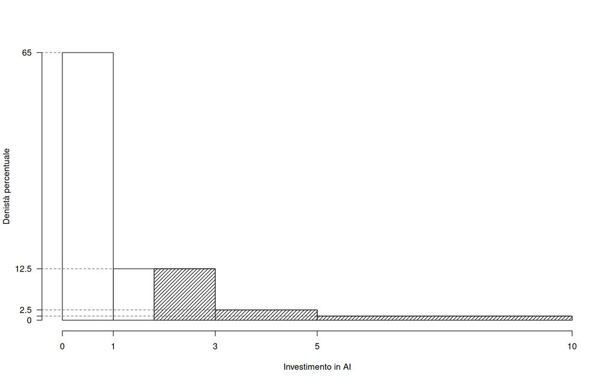

**1.b** (pt 1.2/31→4/103) Qual è la percentuale di aziende che hanno investito tra il 20-esimo e il 75-esimo percentile?

Per definizione $\%(x_{0.2}<X<x_{0.75})=55\%$ e $\#(x_{0.2}<X<x_{0.75})\approx0.55\times200 =110$

**1.c** (pt 0.6/31→2/103) Che relazione dobbiamo aspettarci tra media, mediana e moda?

**1.d** (pt 0.6/31→2/103) Siano $x_1,...,x_{5}$, $n=5$ numeri tali che
$$\sum_{i=1}^{5} x_i = 15$$
Posto
$$g(x)=\sum_{i=1}^{5}(x_i-x)^2$$
calcolare il valore di $x$ che minimizza $g$.

### Esercizio 2

Un processo viene svolto da due agenti AI, $A$ e $B$. L’agente $A$ commette un numero di allucinazioni che è distribuito secondo una Poisson di parametro 0.05, $X_A \sim \text{Pois}(0.05)$, mentre per l’agente $B$ il numero di allucinazioni è distribuito secondo una Poisson di parametro 0.03, $X_B \sim \text{Pois}(0.03)$, $X_A$ e $X_B$ indipendenti. Il processo finale viene considerato inconsistente se entrambi gli agenti hanno commesso almeno una allucinazione ($X_A\ge 1\cap X_B\ge 1$).

**2.a** (pt 3.9/31→13/103) Calcolare la probabilità che il processo sia inconsistente $P(X_A\ge 1\cap X_B\ge 1)$.

$$\begin{eqnarray*}
P( X_A \geq 1 ) &=& 1-P( X_A < 1 )
\\ &=& 1-\left( \frac{ 0.05 ^{ 0 }}{ 0 !}e^{-
0.05 } \right)\\ &=& 1-( 0.9512
)\\ &=& 1- 0.9512
\\ &=& 0.0488
\end{eqnarray*}$$
$$\begin{eqnarray*}
P( X_B \geq 1 ) &=& 1-P( X_B < 1 )
\\ &=& 1-\left( \frac{ 0.03 ^{ 0 }}{ 0 !}e^{-
0.03 } \right)\\ &=& 1-( 0.9704
)\\ &=& 1- 0.9704
\\ &=& 0.0296
\end{eqnarray*}$$
$$\begin{eqnarray}
P(X_A\ge 1\cap X_B\ge 1) &=& P(X_A\ge 1)P( X_B\ge 1)\\
&=& 0.0488\cdot 0.0296\\
&=& 0.0014
\end{eqnarray}$$

**2.b** (pt 1.2/31→4/103) Si considerino $n=5$ ripetizioni indipendenti del processo. Per ogni ripetizione $i$, sia la VC che vale $X_i=1$ se $X_A\ge 1\cap X_B\ge 1$ è vera e vale zero altrimenti.

Calcolare la probabilità che almeno uno dei 5 processi risulti inconsistente, cioè che in almeno una ripetizione si abbia $X_i = 1$. (*Suggerimento: l’evento complementare di “almeno uno dei 5 processi è inconsistente” è “nessuno dei 5 processi è inconsistente”*)

$$\begin{eqnarray*}
P(X_A\ge 1\cap X_B\ge 1) &=& 0.0014\\
P(\text{almeno una volta}) &=& 1-P(\text{nessuna volta})\\
&=& 1-(1-0.0014)^5\\
&=& 0.0072
\end{eqnarray*}$$

**2.c** (pt 0.6/31→2/103) Sia $Z\sim N(0,1)$ e $Y\sim \text{Pois}(5.4)$, $Z$ e $Y$ indipendenti. Calcolare $E(Z-Y)$ e $V(Z-Y)$.

essendo

$$\begin{align}
E(Z) &= 0; & \qquad V(Z) & = 1\\
E(Y) &=5.4 ; & \qquad V(Y) & = 5.4\\
\end{align}$$

e quindi

$$\begin{eqnarray*}
E(Z-Y) &=& 0-5.4\\
V(Z-Y) &=& 1+5.4\\
\end{eqnarray*}$$

**2.d** (pt 0.6/31→2/103) Siano $A\ne\emptyset$ e $B\ne\emptyset$, tali che $P(A|B)>0$, $A$ e $B$ possono essere incompatibili? Perché?

### Esercizio 3

**3.a** (pt 3.9/31→13/103) Un’urna contiene 1 pallina numerata con $\fbox{0}$, 3 numerate con $\fbox{1}$ e 1 numerata con $\fbox{2}$. Si vince se esce $\fbox{1}$ oppure $\fbox{2}$ e si perde altrimenti. Si estrae 80 volte con reinserimento. Qual è la probabilità che la proporzione di vincite sia maggiore di 0.75?

**Teorema del Limite Centrale (proporzione)**

Siano $X_1$,…,$X_n$, $n=80$ VC IID, tc $X_i\sim\text{Ber}(\pi=0.8)$$,\forall i$, posto:
$$\hat\pi=\frac{S_n}n = \frac{X_1 + ... + X_n}n$$
allora:
$$\begin{eqnarray*}
\hat\pi & \mathop{\sim}\limits_{a}& N(\pi,\pi(1-\pi)/n) \\
&\sim & N\left(0.8,\frac{0.8\cdot(1-0.8)}{80}\right) \\
&\sim & N(0.8,0.002)
\end{eqnarray*}$$
$$\begin{eqnarray*}
P( \hat\pi > 0.75 )
&=& P\left( \frac { \hat\pi - \pi }{
\sqrt{\pi(1-\pi)/n} } > \frac { 0.75 - 0.8 }{\sqrt{ 0.002 }}
\right) \\
&=& P\left( Z > -1.12 \right)
\\ &=& 1-P(Z< -1.12 )\\
&=& 1-(1-\Phi( 1.12 )) \\ &=& 0.8686
\end{eqnarray*}$$

### Esercizio 4

**4.a** (pt 0.9/31→3/103) Siano $\hat\beta_0$, $\hat\beta_1$ e $\hat\sigma_\varepsilon$ gli stimatori di massima verosimiglianza di, $\beta_0$, $\beta_1$ e $\sigma_\varepsilon$, del modello di regressione lineare semplice
$$y_i = \beta_0 + \beta_1 x_i +\varepsilon_i, ~\varepsilon_i\sim
N(0,\sigma^2_\varepsilon),\forall i=1,...,n$$
Scrivere il $MSE$ di $\hat\beta_0$.

Sappiamo che $\hat\beta_0$ è stimatore corretto di $\beta_0$ (teroema di Gauss-Markov):
$$E(\hat\beta_0)=\beta_0$$
Quindi, essendo corretto
$$\begin{eqnarray}
MSE(\hat\beta_0) &=& V(\hat\beta_0)\\
&=&\sigma_{\varepsilon}^{2} \left( \frac{1}
{n} + \frac{\bar{x}^{2}} {n \hat{\sigma}^{2}_{X}}
\right)\qquad\text{dal formulario}
\end{eqnarray}$$

**4.b** (pt 0.9/31→3/103) Siano $\hat\theta_1$ e $\hat\theta_2$ due stimatori **corretti** per $\theta$, cosa significa dire che $\hat\theta_1$ è più efficiente di $\hat\theta_2$?

**4.c** (pt 0.9/31→3/103) Definire gli errori di primo e secondo tipo di un test statistico e le relative probabilità.

Si definiscono

- L’**errore di primo tipo** è l’errore che si commette scegliendo $H_1$ quando è vera $H_0$.
- L’**errore di secondo tipo** è l’errore che si commette scegliendo $H_0$ quando è vera $H_1$.

|  |  | Decisione decido $H_0$ | Decisione decido $H_1$ |
| --- | --- | --- | --- |
| stato di natura | $H_0$ | $1-\alpha$ | $\alpha$ |
| stato di natura | $H_1$ | $\beta$ | $1-\beta$ |

$$\alpha=P(\text{Errore I
tipo})=P(\text{Decidere $H_1$};H_0)$$

$$\beta=P(\text{Errore II
tipo})=P(\text{Decidere $H_0$};H_1)$$

- $\alpha$ è il livello di **significatività** del test, $\alpha$ è la probabilità di scegliere $H_1$ quando invece è vera $H_0$.
- $\beta$ è la probabilità di scegliere $H_0$ quando invece è vera $H_1$.

**4.d** (pt 0.9/31→3/103) In un sondaggio su 160 persone è stato chiesto il livello di utilizzo di strumenti di Intelligenza Artificiale (Basso, Medio, Alto) e l’opinione sul loro impatto nel mondo del lavoro (Favorevole, Contrario).

|  | Livello di utilizzo Basso | Livello di utilizzo Medio | Livello di utilizzo Alto |
| --- | --- | --- | --- |
| **Opinione** |  |  |  |
| Favorevole | 30 | 10 | 35 |
| Contrario | 20 | 40 | 25 |

Eseguito il test del $\chi^2$ per verificare l’indipendenza tra il livello di utilizzo degli strumenti di AI e l’opinione sul loro impatto nel mondo del lavoro, si ottiene un $p_\text{value}=0.00002588$. Possiamo concludere che il livello di utilizzo e l’opinione sul loro impatto nel mondo del lavoro sono indipendenti? Perché?

Essendo $p_\text{value}=0.00002588<0.001$ il test è estremamente significativo, si rifiuta l’indipendenza tra il livello di utilizzo e l’opinione sull’impatto ad un livello di significatività inferiore all’1 per mille.

### Esercizio 5

In uno studio su $n=50$ municipalità dell’Unione Europea, sono stati analizzati il tasso di disoccupazione giovanile (in percentuale, $X$) e la disponibilità di aree verdi urbane (in metri quadrati per abitante, $Y$).

Si sono osservate le seguenti statistiche:
$$\begin{align*}
\sum_{i=1}^n x_i &= 498, &\sum_{i=1}^n x_i^2 &= 5025.18
& \\
\sum_{i=1}^n y_i &= 1289.27, &\sum_{i=1}^n y_i^2 &=
36923.54 &\sum_{i=1}^n x_iy_i &= 12393.43.
\end{align*}$$

**5.a** (pt 3.9/31→13/103) Per la regione $R$ si è osservato $x_R=10.6$ e $y_R=24.48$, stimare il modello di regressione dove $Y$ viene spiegata da $X$ e calcolare il residuo per la regione $R$.

$$\begin{eqnarray*}
\bar x &=&\frac 1 n\sum_{i=1}^n x_i = \frac {1}{ 50
} 498 = 9.96 \\
\bar y &=&\frac 1 n\sum_{i=1}^n y_i = \frac {1}{ 50
} 1289.27 = 25.79 \\
\hat\sigma_X^2&=&\frac 1 n\sum_{i=1}^n x_i^2-\bar
x^2=\frac {1}{ 50 } 5025 - 9.96 ^2= 1.302 \\
\hat\sigma_Y^2&=&\frac 1 n\sum_{i=1}^n y_i^2-\bar
y^2=\frac {1}{ 50 } 36924 - 25.7854 ^2= 73.58 \\
\text{cov}(X,Y)&=&\frac 1 n\sum_{i=1}^n x_i~y_i-\bar
x\bar y=\frac {1}{ 50 } 12393 - 9.96 \cdot 25.7854 = -8.954 \\
\hat\beta_1 &=&
\frac{\text{cov}(X,Y)}{\hat\sigma_X^2} \\
&=& \frac{ -8.954 }{ 1.302 } = -6.877 \\
\hat\beta_0 &=& \bar y - \hat\beta_1 \bar x\\
&=& 25.79 - (-6.8771) \times 9.96 = 94.28
\end{eqnarray*}$$
$$\begin{eqnarray*}
\hat y_i &=&\hat\beta_0+\hat\beta_1 x_i=\\
&=& 94.28 + (-6.8771) \times 10.6 = 21.38 \\
\hat \varepsilon_i &=& y_i-\hat y_i\\
&=& 24.48 - 21.3841 = 3.098
\end{eqnarray*}$$

**5.b** (pt 1.2/31→4/103) Determinare la percentuale di varianza spiegata dal modello.

$$\begin{eqnarray*}
r&=&\frac{\text{cov}(X,Y)}{\sigma_X\sigma_Y}=\frac{ -8.954 }{
1.141 \times 8.578 }= -0.9148 \\
r^2&=& 0.8368 > 0.75
\end{eqnarray*}$$

Il modello si adatta bene ai dati.

Il modello spiega il $83.68\%$ della variabilità totale della $Y$.

**5.c** (pt 3.9/31→13/103) Testare l’ipotesi che $\beta_1 = -5$ contro l’alternativa che sia diverso, per $\alpha=0.1,0.05,0.01,0.001$ e dare una valutazione approssimativa del $p_\text{value}$ (ad esempio il $p_\text{value}$ è minore di 0.001, compreso tra 0.05 e tra 0.01, ecc.).

$\fbox{A}$ FORMULAZIONE DELLE IPOTESI

$$\begin{cases}
H_0: \beta_1 = \beta_{1;H_0}=-5 \\
H_1: \beta_1 \neq \beta_{1;H_0}=-5
\end{cases}$$

$\fbox{B}$ SCELTA E CALCOLO STATISTICA-TEST, $T$ Test su un coefficiente di regressione: $\Rightarrow$ t-Test.

$$\begin{eqnarray*}
\hat{\sigma_\varepsilon}^2&=&(1-r^2)\hat\sigma_Y^2\\
&=& (1- 0.8369 )\times 73.58 \\
&=& 12.01 \\
S_\varepsilon^2 &=& \frac{n} {n-2}
\hat{\sigma_\varepsilon}^2\\
&=& \frac{ 50 } { 50 -2} \hat{\sigma_\varepsilon}^2 \\
&=& \frac{ 50 } { 50 -2} \times 12.01 = 12.51
\end{eqnarray*}$$

E quindi
$$\begin{eqnarray*}
V(\hat\beta_{1}) &=& \frac{\sigma_{\varepsilon}^{2}} {n
\hat{\sigma}^{2}_{X}} \\
\widehat{V(\hat\beta_{1})} &=& \frac{S_{\varepsilon}^{2}} {n
\hat{\sigma}^{2}_{X}} \\
&=& \frac{ 12.51 } { 50 \times 1.302 } = 0.1921 \\
\widehat{SE(\hat\beta_{1})} &=& \sqrt{ 0.1921 }\\
&=& 0.4383
\end{eqnarray*}$$

$$\begin{eqnarray*}
\frac{\hat\beta_{ 1 } - \beta_{ 1 ;H_0}} {\widehat{SE(\hat\beta_{ 1
})}}&\sim&t_{n-2}\\
t_{\text{obs}}
&=& \frac{ ( -6.877 - -5 )} { 0.4383 }
= -4.282 \, .
\end{eqnarray*}$$

$\fbox{C}$ CONCLUSIONE

Siccome $H_1$ è bilaterale, considereremo $\alpha/2$, anziché $\alpha$

$\alpha=0.1, 0.05, 0.01, 0.001$ e quindi $\alpha/2=0.05, 0.025, 0.005, 0.0005$

I valori critici sono

$t_{50-2;0.05}=1.6772$; $t_{50-2;0.025}=2.0106$; $t_{50-2;0.005}=2.6822$; $t_{50-2;0.0005}=3.5051$

Siccome $|t_\text{obs}|=4.2823>3.5051$, quindi **rifiuto** $H_0$ sotto all’1‰,

$p_\text{value}<0.001$, *estremamente significativo* $\fbox{***}$.

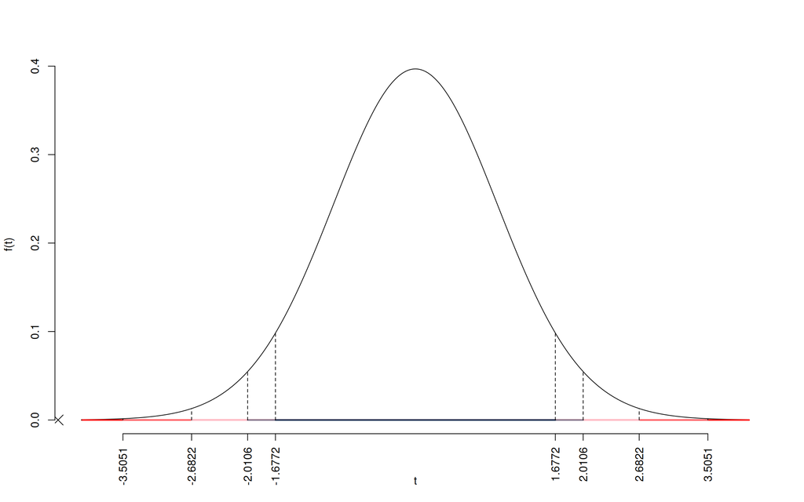

Il $p_{\text{value}}$ è

$$p_{\text{value}} =
P(|T_{50-2}|>|-4.28|)=2P(T_{50-2}>4.28)=0.000088$$

Attenzione il calcolo del $p_\text{value}$ con la $T$ è puramente illustrativo e non può essere riprodotto senza una calcolatrice statistica adeguata.
$$0 < p_\text{value}= 0.000088 \leq 0.001$$

**5.d** (pt 0.6/31→2/103) Perché, nel modello stimato al punto 5a, è più affidabile una previsione per $x=10$ o per $x=0$? Perché?

**5.e** (pt 0.6/31→2/103) Se in un modello di regressione $r =0$ quanto vale $\hat\beta_1$?

**5.f** (pt 0.6/31→2/103) Cosa significa dire che $r$ è invariante ai cambiamenti di scala?

# Prova di Statistica 2

### Esercizio 1

Su un campione di $150$ aziende con più di 50 addetti dell’Emilia-Romagna è stato rilevato l’investimento effettuato negli ultimi 5 anni in intelligenza artificiale (espresso in milioni di euro). Di seguito è riportata la distribuzione delle densità percentuali:

| $[\text{x}_j,$ | $\text{x}_{j+1})$ | $h_j$ |
| --- | --- | --- |
| 0 | 1 | 30.0 |
| 1 | 2 | 40.0 |
| 2 | 6 | 5.0 |
| 6 | 10 | 2.5 |

**1.a** (pt 3.9/31→13/103) Calcolare il valore approssimativo della mediana.

| $[\text{x}_j,$ | $\text{x}_{j+1})$ | $n_j$ | $f_j$ | $b_j$ | $h_j$ |
| --- | --- | --- | --- | --- | --- |
| 0 | 1 | 45 | 0.3 | 1 | 30.0 |
| 1 | 2 | 60 | 0.4 | 1 | 40.0 |
| 2 | 6 | 30 | 0.2 | 4 | 5.0 |
| 6 | 10 | 15 | 0.1 | 4 | 2.5 |
|  |  | 150 | 1.0 | 10 |  |

$$\begin{eqnarray*}
p &=& 0.5 , \text{essendo }F_{ 2 }= 0.7 >
0.5 \Rightarrow j_{ 0.5 }= 2 \\
x_{ 0.5 } &=& x_{\text{inf}; 2 } + \frac{ { 0.5 } - F_{ 1 }}
{f_{ 2 }} \cdot b_{ 2 } \\
&=& 1 + \frac {{ 0.5 } - 0.3 } { 0.4 }
\cdot 1 \\
&=& 1.5
\end{eqnarray*}$$

[figure not shown]

**1.b** (pt 1.2/31→4/103) Qual è la percentuale approssimativa di aziende che hanno investito meno di 3 milioni di euro?

$$\begin{eqnarray*}
\%(X< 3 ) &=& f_{ 1 }\times 100+f_{ 2 }\times 100 +( 3
- 2 )\times h_{ 3 } \\
&=& ( 0.3 )\times 100+( 0.4 )\times 100 +( 1
)\times 5 \\
&=& 0.75 \times(100) \\
\#(X< 3 ) &\approx& 112
\end{eqnarray*}$$

**1.c** (pt 0.6/31→2/103) Sapendo che le media è pari a $2.4$ e considerata la mediana calcolata al punto 1.a, che forma avrà l’istogramma di densità?

**1.d** (pt 0.6/31→2/103) Cosa significa dire che la media aritmetica gode della proprietà associativa?

Significa che data una popolazione, $\mathscr{P}$, formata da $K$ gruppi con medie e numerosità: ($\bar{x}_{1};\ n_{1}$), ($\bar{x}_{2};\ n_{2}$), $\ldots$, ($\bar{x}_{K};\ n_{K}$). Allora, la media totale $\bar{x}_{T}$ di $\mathscr{P}=$ è data da

$$\bar{x}_{T}
= \frac{\mbox{Tot}{ \{\mathscr{P}}_1\} + \cdots +
\mbox{Tot}{ \{\mathscr{P}}_K\}} {n_{1} + \cdots + n_{K}}
= \frac{n_{1}\ \bar{x}_{1} + \cdots + n_{K}\ \bar{x}_{K}}
{n_{1} + \cdots + n_{K}}$$

### Esercizio 2

Un processo viene svolto da due agenti AI in parallelo, $A$ e $B$. Il tempo impiegato da ciascun agente, misurato in secondi, è distribuito secondo una Normale con media 7 e varianza 2, $X_A \sim N(7,2)$, $X_B \sim N(7,2)$, con $X_A$ e $X_B$ indipendenti. Il processo finale viene considerato troppo lento se almeno uno dei due agenti impiega più di 10 secondi, cioè se $\{X_A> 10\} \cup \{X_B>10\}$.

**2.a** (pt 3.9/31→13/103) Calcolare la probabilità che il processo sia troppo lento ($\{X_A> 10\} \cup \{X_B>10\}$).

**2.b** (pt 1.2/31→4/103) Calcolare $P(X_A \le 10|X_A > 8)$.

**2.c** (pt 0.6/31→2/103) Siano $X_1\sim \text{Pois}(0.5)$, $X_2\sim \text{Pois}(0.5)$ e $X_3\sim \text{Pois}(0.5)$, 3 Poisson indipendenti. Come si distribuisce $X=X_1+X_2+X_3$?

$$X_1+X_2+X_3 \sim \text{Pois}(3\times 0.5)$$

**2.d** (pt 0.6/31→2/103) Siano $A$ e $B$ due eventi, tali che $P(A|B)=0.5$, $P(A|\bar B)=0.4$ e $P(B)=0.3$, calcolare $P(A)$.

$$\begin{eqnarray*}
P(A) &=& P(A|B)P(B)+P(A|bar B)P(\bar B)\\
&=& 0.5\times 0.3+ 0.4\times(1-0.3)\\
&=& 0.43
\end{eqnarray*}$$

### Esercizio 3

**3.a** (pt 3.9/31→13/103) Un’urna contiene 1 pallina numerata con $\fbox{0}$, 3 numerate con $\fbox{1}$ e 1 numerata con $\fbox{2}$. Si vince se esce $\fbox{1}$ oppure $\fbox{2}$ e si perde altrimenti. Si estrae 80 volte con reinserimento. Qual è la probabilità di vincere meno di 60 volte?

**Teorema del Limite Centrale (somma di Bernoulli)**

Siano $X_1$,…,$X_n$, $n=80$ VC IID, tc $X_i\sim\text{Ber}(\pi=0.8)$$,\forall i$, posto:
$$S_n = X_1 + ... + X_n$$
allora:
$$\begin{eqnarray*}
S_n & \mathop{\sim}\limits_{a}& N(n\pi,n\pi(1-\pi)) \\
&\sim & N(80\cdot0.8,80\cdot0.8\cdot(1-0.8)) \\
&\sim & N(64,12.8)
\end{eqnarray*}$$
$$\begin{eqnarray*}
P( S_n < 60 )
&=& P\left( \frac { S_n - n\pi }{ \sqrt{n\pi(1-\pi)}
} < \frac { 60 - 64 }{\sqrt{ 12.8 }} \right) \\
&=& P\left( Z < -1.12 \right) \\
&=& 1-\Phi( 1.12 ) \\ &=& 0.1314
\end{eqnarray*}$$

### Esercizio 4

**4.a** (pt 0.9/31→3/103) Siano $\hat\beta_0$, $\hat\beta_1$ e $\hat\sigma_\varepsilon$ gli stimatori di massima verosimiglianza di, $\beta_0$, $\beta_1$ e $\sigma_\varepsilon$, del modello di regressione lineare semplice
$$y_i = \beta_0 + \beta_1 x_i +\varepsilon_i, ~\varepsilon_i\sim
N(0,\sigma^2_\varepsilon),\forall i=1,...,n$$
Scrivere il $MSE$ di $\hat\beta_1$.

Sappiamo che $\hat\beta_1$ è stimatore corretto di $\beta_1$ (teorema di Gauss-Markov):
$$E(\hat\beta_1)=\beta_1$$
Quindi, essendo corretto
$$\begin{eqnarray}
MSE(\hat\beta_1) &=& V(\hat\beta_1)\\
&=&\frac{\sigma_{\varepsilon}^{2}} {n
\hat{\sigma}^{2}_{X}} \qquad \text{dal formulario}
\end{eqnarray}$$

**4.b** (pt 0.9/31→3/103) Siano $\hat\theta_1$ e $\hat\theta_2$ due stimatori **non corretti** per $\theta$, cosa significa dire che $\hat\theta_1$ è più efficiente di $\hat\theta_2$?

**4.c** (pt 0.9/31→3/103) Si consideri il seguente sistema d’ipotesi:
$$\begin{cases}
H_0:\theta=\theta_0\\
H_1:\theta>\theta_0
\end{cases}$$

Posta con $T$ la VC statistica test e con $t_\text{obs}$ il valore osservato della statistica test, definire il $p_\text{value}$ del test.

Il $p_\text{value}$ è la probabilità, se fosse vera $H_0$ di avere un campione ancora più favorevole ad $H_1$ di quello che abbiamo osservato, in altre parole ci dice quanto è raro il campione sotto ipotesi $H_0$. In simboli, nel caso di un test unilaterale destro
$$p_\text{value} = P(T>t_\text{obs})$$

**4.d** (pt 0.9/31→3/103) In un sondaggio su 273 lavoratori è stato chiesto il livello di formazione ricevuta sull’uso degli strumenti di Intelligenza Artificiale (Basso, Medio, Alto) e la valutazione della propria preparazione rispetto ai cambiamenti tecnologici nel lavoro (Adeguata, Insufficiente).

|  | Livello di formazione Basso | Livello di formazione Medio | Livello di formazione Alto |
| --- | --- | --- | --- |
| **Preparazione** |  |  |  |
| Adeguata | 18 | 32 | 45 |
| Insufficiente | 40 | 40 | 98 |

Eseguito il test del $\chi^2$ per verificare l’indipendenza tra il livello di formazione sugli strumenti di AI e la valutazione della preparazione rispetto ai cambiamenti tecnologici, si ottiene un $p_\text{value}=0.1344$. Possiamo concludere che il livello di formazione ricevuta e la propria valutazione rispetto alla propria preparazione sono indipendenti? Perché?

Essendo $p_\text{value}=0.1344>0.1$ il test non è significativo, non si rifiuta l’indipendenza tra il livello di utilizzo e l’opinione sull’impatto per nessun livello di significatività.

### Esercizio 5

In uno studio su $n=50$ municipalità dell’Unione Europea, sono stati analizzati il tasso di disoccupazione giovanile (in percentuale, $X$) e il numero di posti a sedere in teatro e cinema per abitante ($Y$).

Si sono osservate le seguenti statistiche:
$$\begin{align*}
\sum_{i=1}^n x_i &= 500.4, &\sum_{i=1}^n x_i^2 &= 5047.02
& \\
\sum_{i=1}^n y_i &= 114.68, &\sum_{i=1}^n y_i^2 &= 263.79
&\sum_{i=1}^n x_iy_i &= 1151.3.
\end{align*}$$

**5.a** (pt 3.9/31→13/103) Per la regione $R$ si è osservato $x_R=10.5$ e $y_R=2.19$, stimare il modello di regressione dove $Y$ viene spiegata da $X$ e calcolare il residuo per la regione $R$.

$$\begin{eqnarray*}
\bar x &=&\frac 1 n\sum_{i=1}^n x_i = \frac {1}{ 50
} 500.4 = 10.01 \\
\bar y &=&\frac 1 n\sum_{i=1}^n y_i = \frac {1}{ 50
} 114.68 = 2.294 \\
\hat\sigma_X^2&=&\frac 1 n\sum_{i=1}^n x_i^2-\bar
x^2=\frac {1}{ 50 } 5047 - 10.008 ^2= 0.7803 \\
\hat\sigma_Y^2&=&\frac 1 n\sum_{i=1}^n y_i^2-\bar
y^2=\frac {1}{ 50 } 263.8 - 2.2936 ^2= 0.0152 \\
\text{cov}(X,Y)&=&\frac 1 n\sum_{i=1}^n x_i~y_i-\bar
x\bar y=\frac {1}{ 50 } 1151 - 10.008 \cdot 2.2936 = 0.07166 \\
\hat\beta_1 &=&
\frac{\text{cov}(X,Y)}{\hat\sigma_X^2} \\
&=& \frac{ 0.07166 }{ 0.7803 } = 0.09183
\\
\hat\beta_0 &=& \bar y - \hat\beta_1 \bar x\\
&=& 2.294 - 0.0918 \times 10.008 = 1.375
\end{eqnarray*}$$
$$\begin{eqnarray*}
\hat y_i &=&\hat\beta_0+\hat\beta_1 x_i=\\
&=& 1.375 + 0.0918 \times 10.5 = 2.339 \\
\hat \varepsilon_i &=& y_i-\hat y_i\\
&=& 2.192 - 2.3388 = -0.1471
\end{eqnarray*}$$

**5.b** (pt 1.2/31→4/103) Determinare la percentuale di varianza spiegata dal modello.

$$\begin{eqnarray*}
r&=&\frac{\text{cov}(X,Y)}{\sigma_X\sigma_Y}=\frac{ 0.07166 }{
0.8834 \times 0.1233 }= 0.658 \\
r^2&=& 0.4329 < 0.75
\end{eqnarray*}$$

Il modello **non** si adatta bene ai dati.

Il modello spiega il $43.29\%$ della variabilità totale della $Y$.

**5.c** (pt 3.9/31→13/103) Testare l’ipotesi che $\beta_0 = 1$ contro l’alternativa che sia maggiore, per $\alpha=0.1,0.05,0.01,0.001$ e dare una valutazione approssimativa del $p_\text{value}$ (ad esempio il $p_\text{value}$ è minore di 0.001, compreso tra 0.05 e tra 0.01, ecc.).

$\fbox{A}$ FORMULAZIONE DELLE IPOTESI

$$\begin{cases}
H_0: \beta_0 = \beta_{0;H_0}=1 \\
H_1: \beta_0 > \beta_{0;H_0}=1
\end{cases}$$

$\fbox{B}$ SCELTA E CALCOLO STATISTICA-TEST, $T$ Test su un coefficiente di regressione: $\Rightarrow$ t-Test.

$$\begin{eqnarray*}
\hat{\sigma_\varepsilon}^2&=&(1-r^2)\hat\sigma_Y^2\\
&=& (1- 0.433 )\times 0.0152 \\
&=& 0.0086 \\
S_\varepsilon^2 &=& \frac{n} {n-2}
\hat{\sigma_\varepsilon}^2\\
&=& \frac{ 50 } { 50 -2} \hat{\sigma_\varepsilon}^2 \\
&=& \frac{ 50 } { 50 -2} \times 0.0086 = 0.009
\end{eqnarray*}$$

E quindi
$$\begin{eqnarray*}
V(\hat\beta_{0}) &=& \sigma_{\varepsilon}^{2} \left( \frac{1}
{n} + \frac{\bar{x}^{2}} {n \hat{\sigma}^{2}_{X}} \right)\\
\widehat{V(\hat\beta_{0})} &=& S_{\varepsilon}^{2}\left(
\frac{1} {n} + \frac{\bar{x}^{2}} {n \hat{\sigma}^{2}_{X}} \right)\ \\
&=& 0.009 \times\left( \frac{1} { 50 } + \frac{ 10.01 ^{2}} {
50 \times 0.7803 } \right)\\
\widehat{SE(\hat\beta_{0})} &=& \sqrt{ 0.0232 }\\
&=& 0.1523
\end{eqnarray*}$$
$$\begin{eqnarray*}
\frac{\hat\beta_{ 0 } - \beta_{ 0 ;H_0}} {\widehat{SE(\hat\beta_{ 0
})}}&\sim&t_{n-2}\\
t_{\text{obs}}
&=& \frac{ ( 1.375 - 1 )} { 0.1524 }
= 2.458 \, .
\end{eqnarray*}$$

$\fbox{C}$ CONCLUSIONE

Consideriamo $\alpha=0.1, 0.05, 0.01, 0.001$

I valori critici sono

$t_{50-2;0.1}=1.2994$; $t_{50-2;0.05}=1.6772$; $t_{50-2;0.01}=2.4066$; $t_{50-2;0.001}=3.2689$

Siccome $2.4066<t_\text{obs}=2.4579<3.2689$, quindi **rifiuto** $H_0$ all’1%,

$0.001<p_\text{value}<0.01$, *molto significativo* $\fbox{**}$.

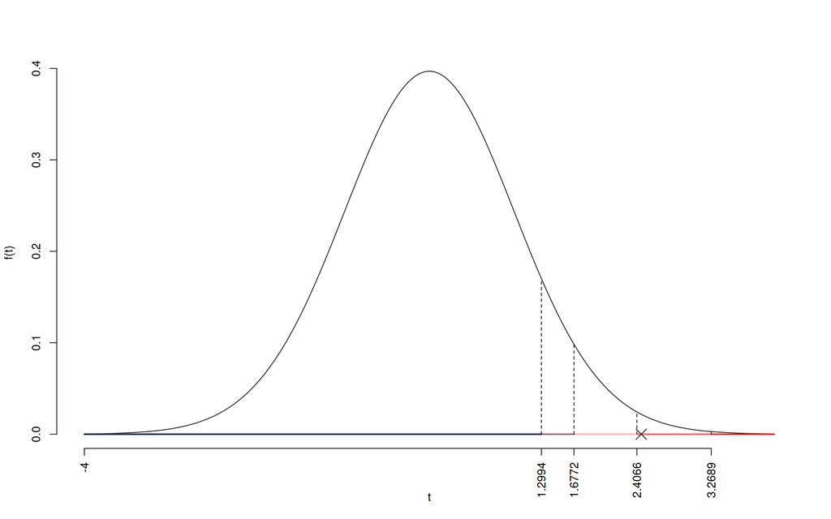

Il $p_{\text{value}}$ è

$$p_{\text{value}} =
P(T_{50-2}>2.46)=0.008819$$

Attenzione il calcolo del $p_\text{value}$ con la $T$ è puramente illustrativo e non può essere riprodotto senza una calcolatrice statistica adeguata.
$$0.001 < p_\text{value}= 0.008819 \leq 0.01$$

**5.d** (pt 0.6/31→2/103) Che differenza c’è tra interpolazione ed estrapolazione?

**5.e** (pt 0.6/31→2/103) Se in un modello di regressione $r <0$ che segno avrà $\hat\beta_1$?

**5.f** (pt 0.6/31→2/103) In un modello di regressione lineare, cosa comporta $r=-1$?

# Prova di Statistica 3

### Esercizio 1

Su un campione di $200$ aziende con più di 50 addetti dell’Emilia-Romagna è stato rilevato l’investimento effettuato negli ultimi 5 anni in intelligenza artificiale (espresso in milioni di euro). Di seguito è riportata la distribuzione delle frequenze cumulate:

| $[\text{x}_j,$ | $\text{x}_{j+1})$ | $F_j$ |
| --- | --- | --- |
| 0 | 2 | 0.10 |
| 2 | 3 | 0.50 |
| 3 | 7 | 0.95 |
| 7 | 15 | 1.00 |

**1.a** (pt 3.9/31→13/103) Individuare la classe modale.

| $[\text{x}_j,$ | $\text{x}_{j+1})$ | $n_j$ | $f_j$ | $b_j$ | $h_j$ |
| --- | --- | --- | --- | --- | --- |
| 0 | 2 | 20 | 0.10 | 2 | 5.00 |
| 2 | 3 | 80 | 0.40 | 1 | 40.00 |
| 3 | 7 | 90 | 0.45 | 4 | 11.25 |
| 7 | 15 | 10 | 0.05 | 8 | 0.62 |
|  |  | 200 | 1.00 | 15 |  |

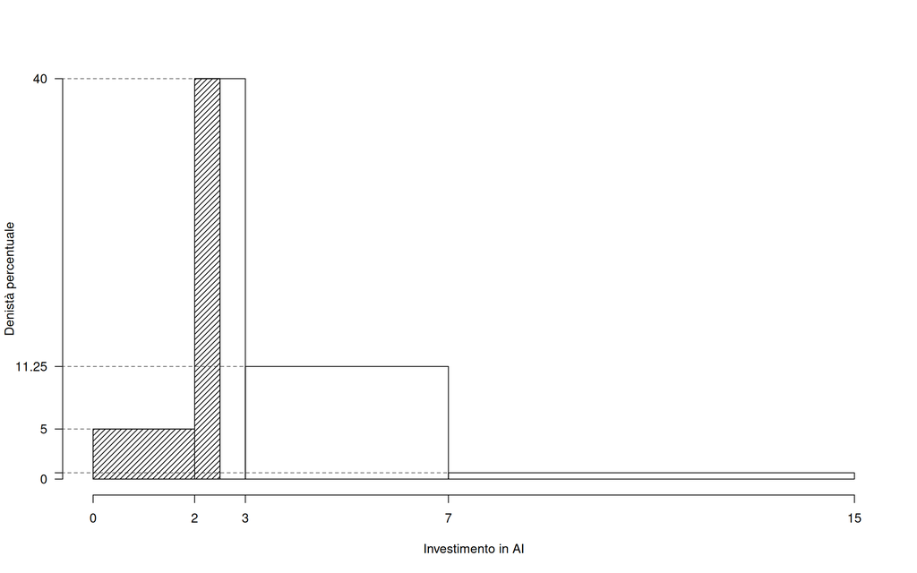

**1.b** (pt 1.2/31→4/103) Qual è la percentuale di aziende che hanno investito tra il 15-esimo e il 50-esimo percentile?

Per definizione $\%(x_{0.15}<X<x_{0.5})=35\%$ e $\#(x_{0.15}<X<x_{0.5})\approx0.35\times200 =70$

**1.c** (pt 0.6/31→2/103) Sapendo che le media è pari a $3.9$ e considerata la mediana calcolata al punto 1.a, che forma avrà l’istogramma di densità?

**1.d** (pt 0.6/31→2/103) L’investimento medio è pari a $\bar x=3.9$, mentre la SD è pari a $\sigma=2.2$. Se ogni impresa diminuisse il proprio investimento del 10%, quanto varrebbero la media e la SD dei dati così trasformati?

$$\bar y= 3.51 ~~~~~~~~ \sigma_Y= 1.98$$

### Esercizio 2

Un processo è svolto da $n=5$ agenti AI, ogni agente commette un’allucinazione con probabilità $\pi=0.25$. Sia $X_i$ la VC che vale 1 se l’agente $i$ ha commesso un’allucinazione e vale 0 altrimenti:
$$P(X_i = 1) = 0.25, \qquad i =1,...,5$$
e sia
$$X=X_1+...+X_5$$
la VC che conta il numero di allucinazioni su 5 agenti.

**2.a** (pt 3.9/31→13/103) Calcolare la probabilità che il processo abbia almeno un’allucinazione ($P(X\ge 1)$).

$$X=X_1 + ... + X_5 \sim \operatorname{Binom}(5;0.25)$$
$$\begin{eqnarray*}
P( X \geq 1 ) &=& 1-P( X < 1 )
\\ &=& 1-\left( \binom{ 5 }{ 0 } 0.25 ^{ 0 }(1-
0.25 )^{ 5 - 0 } \right)\\ &=& 1-( 0.2373
)\\ &=& 1- 0.2373
\\ &=& 0.7627
\end{eqnarray*}$$

**2.b** (pt 1.2/31→4/103) Calcolare $P(X\ge 2|X\ge 1)$.

$$X=X_1 + ... + X_5 \sim \operatorname{Binom}(5;0.25)$$

**2.c** (pt 0.6/31→2/103) Siano $Z\sim N(0,1)$, $X\sim \chi^2_2$ e $Y\sim \chi^2_5$, $X$, $Y$ e $Z$ indipendenti. Come si distribuisce
$$Z^2+X+Y\sim~~?$$

Siccome
$$Z^2 \sim \chi^2_1$$

allora

$$Z^2+X+Y \sim \chi^2_{1+2+5}$$

**2.d** (pt 0.6/31→2/103) Siano $A$ e $B$ due eventi tali che $P(A)=0.4$ e $P(B)=0.6$, dimostrare che se $A$ e $B$ sono incompatibili, allora $B=\bar A$.

Siccome $A$ e $B$ sono incompatibili
$$P(A\cup B)= P(A)+P(B)=0.4+0.6= 1 = P(\Omega)$$
Da cui
$$A\cup B = \Omega \qquad \text{e} \qquad A\cap B=\emptyset$$
da cui
$$B = \bar A$$

### Esercizio 3

**3.a** (pt 3.9/31→13/103) Un’urna contiene 1 pallina numerata con $\fbox{0}$, 3 numerate con $\fbox{1}$ e 1 numerata con $\fbox{2}$. Si estrae 80 volte con reinserimento. Qual è la probabilità che la somma delle 80 palline sia inferiore a 75?

$$\begin{eqnarray*}
\mu &=& \frac 1{ 5 }( 0 + 1 + 1 + 1 + 2 )= 1 \\
\sigma^2 &=& \frac 1{ 5 }( 0 ^2+ 1 ^2+ 1 ^2+ 1 ^2+ 2 ^2 )-( 1
)^2= 0.4
\end{eqnarray*}$$
**Teorema del Limite Centrale (somma VC qualunque)**

Siano $X_1$,…,$X_n$, $n=80$ VC IID, tc $E(X_i)=\mu=1$ e $V(X_i)=\sigma^2=0.4,\forall i$, posto:
$$S_n = X_1 + ... + X_n$$
allora:
$$\begin{eqnarray*}
S_n & \mathop{\sim}\limits_{a}& N(n\mu,n\sigma^2) \\
&\sim & N(80\cdot1,80\cdot0.4) \\
&\sim & N(80,32)
\end{eqnarray*}$$
$$\begin{eqnarray*}
P( S_n < 75 )
&=& P\left( \frac { S_n - n\mu }{ \sqrt{n\sigma^2}
} < \frac { 75 - 80 }{\sqrt{ 32 }} \right) \\
&=& P\left( Z < -0.88 \right) \\
&=& 1-\Phi( 0.88 ) \\ &=& 0.1894
\end{eqnarray*}$$

### Esercizio 4

**4.a** (pt 0.9/31→3/103) Siano $\hat\beta_0$, $\hat\beta_1$ e $\hat\sigma_\varepsilon$ gli stimatori di massima verosimiglianza di, $\beta_0$, $\beta_1$ e $\sigma_\varepsilon$, del modello di regressione lineare semplice
$$y_i = \beta_0 + \beta_1 x_i +\varepsilon_i, ~\varepsilon_i\sim
N(0,\sigma^2_\varepsilon),\forall i=1,...,n$$
Sapendo che:
$$V(\hat\sigma_\varepsilon)=\frac{2(n-2)}{n^2}\sigma_\varepsilon^4$$
Scrivere il $MSE$ di $\hat\sigma_\varepsilon^2$.

quindi

$$\operatorname{Bias}(\hat\sigma_\varepsilon^2)
=
E(\hat\sigma_\varepsilon^2)-\sigma_\varepsilon^2
=
-\frac{2}{n}\sigma_\varepsilon^2.$$

Pertanto

$$\begin{aligned}
MSE(\hat\sigma_\varepsilon^2)
&=
V(\hat\sigma_\varepsilon^2)+\operatorname{Bias}^2(\hat\sigma_\varepsilon^2)\\
&=
\frac{2(n-2)}{n^2}\sigma_\varepsilon^4
+
\left(-\frac{2}{n}\sigma_\varepsilon^2\right)^2\\
&=
\frac{2(n-2)+4}{n^2}\sigma_\varepsilon^4\\
&=
\frac{2}{n}\sigma_\varepsilon^4.
\end{aligned}$$

Quindi:

$$MSE(\hat\sigma_\varepsilon^2)=\frac{2}{n}\sigma_\varepsilon^4$$

**4.b** (pt 0.9/31→3/103) Sia $\hat\theta$ lo stimatore di massima verosimiglianza per $\theta$, indicare la sua distribuzione asintotica.

**4.c** (pt 0.9/31→3/103) Definire un intervallo di confidenza al 95% per un generico parametro $\theta$.

Un intervallo di confidenza al livello 95% per $\theta$ è un intervallo costruito sui dati in modo tale che il 95% delle volte contenga il vero parametro $\theta$. Ovvero è una coppia di statistiche $L_1(X_1,...,X_n)<L_2(X_1,...,X_n)$ tali che
$$P([L_1(X_1,...,X_n),L_2(X_1,...,X_n)]\ni\theta)=0.95$$

**4.d** (pt 0.9/31→3/103) Una moneta, che non sappiamo se è perfetta oppure no, viene lanciata 100 volte. Abbiamo osservato 34 volte testa su 100 lanci. Posto $\pi$ la probabilità che la moneta mostri testa, si è testato
$$\begin{cases}
H_0:\pi=\frac 12\\
H_1:\pi\ne\frac 12
\end{cases}$$
ed è risultato $p_\text{value}=0.0014$. Possiamo concludere che la moneta sia truccata? Perché?

### Esercizio 5

In un’indagine sulla penetrazione dell’intelligenza artificiale (IA) nel mondo del lavoro sono state indagate 75 aziende con oltre i 50 dipendenti della regione Lombardia. L’indagine ha mostrato che 45 aziende su 75 hanno integrato i loro processi produttivi con sistemi IA.

**5.a** (pt 0.9/31→3/103) Costruire un intervallo di confidenza al 95 % per la proporzione di aziende che in Lombardia integrano i loro processi con l’IA.

$1-\alpha =0.95$ e quindi $\alpha=0.05\rightarrow \alpha/2=0.025$

$$\hat\pi = \frac{S_n}n = \frac{ 45 }{ 75 }= 0.6$$

$$\begin{eqnarray*}
Idc: & & \hat\pi \pm z_{\alpha/2} \times
\sqrt{\frac{\hat\pi(1-\hat\pi)}{n}} \\
& & 0.6 \pm 1.96 \times \sqrt{\frac{ 0.6 (1- 0.6 )}{ 75
}} \\
& & 0.6 \pm 1.96 \times 0.05657 \\
& & [ 0.4891 , 0.7109 ]
\end{eqnarray*}$$

**5.b** (pt 3.0/31→10/103) Un’indagine analoga, condotta sul territorio nazionale, ha mostrato che la proporzione di aziende che integrano l’IA nei loro processi è pari 0.55. Testare l’ipotesi che la proporzione di aziende che usano le IA nella regione Lombardia sia uguale a quella del resto d’Italia contro l’alternativa che sia maggiore. Risolvere con il $p_\text{value}$ e confrontarlo per $\alpha = 0.1,\ 0.05,\ 0.01,\ 0.001$.

**Test $Z$ per una proporzione**

La stima
$$\hat\pi=\frac { 45 } { 75 }=
0.6$$

$\fbox{A}$ FORMULAZIONE DELLE IPOTESI

$$\begin{cases}
H_0: \pi = \pi_0=0.55 \\
H_1: \pi > \pi_0=0.55
\end{cases}$$

$\fbox{B}$ SCELTA E CALCOLO STATISTICA-TEST, $Z$ Test Binomiale per $n$ grande: $\Rightarrow$ z-Test.

$$\begin{eqnarray*}
\frac{\hat\pi - \pi_{0}} {\sqrt
{\pi_0(1-\pi_0)/\,n}}&\sim&N(0,1)\\
z_{\text{obs}}
&=& \frac{ ( 0.6 - 0.55 )} {\sqrt{ 0.55 (1- 0.55 )/ 75 }}
= 0.8704 \,.
\end{eqnarray*}$$

$\fbox{C}$ CONCLUSIONE

Il $p_{\text{value}}$ è

$$p_{\text{value}} =
P(Z>0.87)=0.192044$$

$$0.1 < p_\text{value}= 0.192044 \leq 1$$

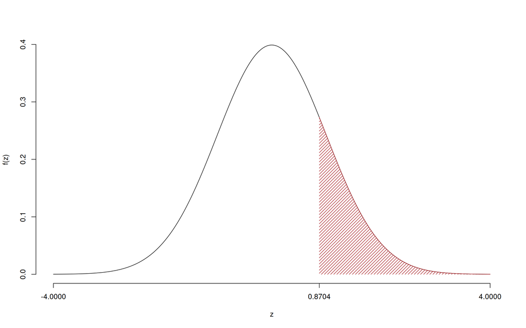

**Non** rifiuto $H_0$ a **nessun** livello di significatività,

$p_\text{value}>0.1$, *non significativo*

### Esercizio 6

In uno studio su $n=50$ municipalità dell’Unione Europea, sono stati analizzati il numero di centraline per la ricarica delle auto elettriche per chilometro quadrato (X) e una misura della qualità dell’aria espressa in opportuna scala (Y).

Si sono osservate le seguenti statistiche:
$$\begin{align*}
\sum_{i=1}^n x_i &= 497.7, &\sum_{i=1}^n x_i^2 &= 5123.67
& \\
\sum_{i=1}^n y_i &= 113.92, &\sum_{i=1}^n y_i^2 &= 262.03
&\sum_{i=1}^n x_iy_i &= 1151.85.
\end{align*}$$

**6.a** (pt 3.9/31→13/103) Per la regione $R$ si è osservato $x_R=10.1$ e $y_R=2.24$, stimare il modello di regressione dove $Y$ viene spiegata da $X$ e calcolare il residuo per la regione $R$.

$$\begin{eqnarray*}
\bar x &=&\frac 1 n\sum_{i=1}^n x_i = \frac {1}{ 50
} 497.7 = 9.954 \\
\bar y &=&\frac 1 n\sum_{i=1}^n y_i = \frac {1}{ 50
} 113.92 = 2.278 \\
\hat\sigma_X^2&=&\frac 1 n\sum_{i=1}^n x_i^2-\bar
x^2=\frac {1}{ 50 } 5124 - 9.954 ^2= 3.391 \\
\hat\sigma_Y^2&=&\frac 1 n\sum_{i=1}^n y_i^2-\bar
y^2=\frac {1}{ 50 } 262 - 2.2784 ^2= 0.04949 \\
\text{cov}(X,Y)&=&\frac 1 n\sum_{i=1}^n x_i~y_i-\bar
x\bar y=\frac {1}{ 50 } 1152 - 9.954 \cdot 2.2784 = 0.3578 \\
\hat\beta_1 &=&
\frac{\text{cov}(X,Y)}{\hat\sigma_X^2} \\
&=& \frac{ 0.3578 }{ 3.391 } = 0.1055 \\
\hat\beta_0 &=& \bar y - \hat\beta_1 \bar x\\
&=& 2.278 - 0.1055 \times 9.954 = 1.228
\end{eqnarray*}$$
$$\begin{eqnarray*}
\hat y_i &=&\hat\beta_0+\hat\beta_1 x_i=\\
&=& 1.228 + 0.1055 \times 10.1 = 2.294 \\
\hat \varepsilon_i &=& y_i-\hat y_i\\
&=& 2.238 - 2.2938 = -0.05583
\end{eqnarray*}$$

**6.b** (pt 1.2/31→4/103) Determinare la percentuale di varianza spiegata dal modello.

$$\begin{eqnarray*}
r&=&\frac{\text{cov}(X,Y)}{\sigma_X\sigma_Y}=\frac{ 0.3578 }{
1.842 \times 0.2225 }= 0.8733 \\
r^2&=& 0.7627 > 0.75
\end{eqnarray*}$$

Il modello si adatta bene ai dati.

Il modello spiega il $76.27\%$ della variabilità totale della $Y$.

**6.c** (pt 0.6/31→2/103) Definire gli outliers e i punti di leva.

**6.d** (pt 0.6/31→2/103) Se in un modello di regressione $\hat\beta_1 >0$ che segno avrà $r$?

**6.e** (pt 0.6/31→2/103) Cosa significa quando $r^2=0$?